# Transcriptomic trajectories

Carlota Myhre de Gouveia

2026-31-08

## Introduction

This report examines transcriptional trajectories across temperature treatments in Western, Southern, and Hybrid corkwing wrasse. First, principal component analysis (PCA) was used to visualize transcriptomic trajectories across temperatures for the whole transcriptome and focal gene sets. Second, unsupervised hierarchical clustering was used to identify major classes of gene-level expression trajectories within each gene set. Finally, South-West expression divergence was quantified across temperatures to evaluate how parental transcriptional differentiation changes across the thermal gradient.

## Package Loading

```r
suppressPackageStartupMessages({
    library(DESeq2)
    library(tidyverse)
    library(here)
    library(ggplot2)
    library(RColorBrewer)
    library(scales)
    library(readxl)
    library(cluster)
    library(readr)
    library(dplyr)
})
```

## Data Import and Preprocessing

```r
# Load transcript abundance matrix
abundance_matrix <- read.table(
  "data/DE/abundance_matrix.txt",
  header = TRUE,
  row.names = 1,
  check.names = FALSE
)

# Simplify sample names
colnames(abundance_matrix) <- sub(
  ".*Melops",
  "",
  colnames(abundance_matrix)
)

# Import metadata
sample_info <- read_excel(
  "data/sample_conditions_rnaseq.xlsx"
) %>%
  mutate(
    sample = sub("L", "", RNA_Later_ID),
    origin = factor(
      Origin,
      levels = c("W", "H", "S")
    ),
    temperature = factor(
      `Temperature (celsius)`,
      levels = c(12, 15, 18)
    ),
    condition = factor(
      RNAseqgroup,
      levels = c(
        "W12", "W15", "W18",
        "H12", "H15", "H18",
        "S12", "S15", "S18"
      )
    ),
    length = scale(`Total length (mm)`)
  ) %>%
  select(
    sample,
    origin,
    temperature,
    condition,
    length
  )

# Reorder metadata to match count matrix
sample_info <- sample_info %>%
  arrange(
    match(
      sample,
      colnames(abundance_matrix)
    )
  )

# Load gene sets
# Tier 1 genes
tier1_genes <- na.omit(
  read.csv(
    "results/functional_enrichment/tier1_shared_temperature_response/tier1_shared_temperature_genes.csv"
  )$gene_id
)

# Tier 2 genes
tier2_genes <- na.omit(
  read.csv(
    "results/functional_enrichment/tier2_pop_divergence/tier2_pop_divergence_genes.csv"
  )$gene_id
)

# Interaction genes
interaction_genes <- read.csv(
  "results/DE/interaction_effects/significant_interaction_genes.csv"
)$transcript_id

# Tier 2b genes
tier2b_genes <- na.omit(
  read.csv(
    "results/functional_enrichment/tier2_pop_divergence/tier2b_local_adaptation/tier2b_local_adaptation_candidates.csv"
  )$gene_id
)

# Tier 3 misexpressed genes
tier3_mis_genes <- na.omit(
  read.csv(
    "results/functional_enrichment/tier3_hybrid_inheritance/tier3_misexpressed_genes.csv"
  )$gene_id
)

# Tier 1 ∩ Tier 3 misexpressed genes
tier1_tier3_mis_genes <- na.omit(
  read.csv(
    "results/functional_enrichment/tier_intersections/tier1_tier3_misexpressed.csv"
  )$gene_id
)

# Tier 2b ∩ Tier 3 misexpressed genes
tier2b_tier3_mis_genes <- na.omit(
  read.csv(
    "results/functional_enrichment/tier_intersections/tier2b_tier3_misexpressed.csv"
  )$gene_id
)

# Summarize gene-set sizes
gene_set_sizes <- tibble(
  Gene_Set = c(
    "Tier 1",
    "Tier 2",
    "Interaction genes",
    "Tier 2b",
    "Tier 3 Misexpressed",
    "Tier1 ∩ Tier3 Misexpr",
    "Tier2b ∩ Tier3 Misexpr"
  ),
  N_Genes = c(
    length(tier1_genes),
    length(tier2_genes),
    length(interaction_genes),
    length(tier2b_genes),
    length(tier3_mis_genes),
    length(tier1_tier3_mis_genes),
    length(tier2b_tier3_mis_genes)
  )
)

# Display gene-set sizes
knitr::kable(
  gene_set_sizes,
  caption = "Gene-set sizes used for trajectory analyses"
)
```

Gene-set sizes used for trajectory analyses

| Gene_Set | N_Genes |
| --- | --- |
| Tier 1 | 593 |
| Tier 2 | 1498 |
| Interaction genes | 977 |
| Tier 2b | 45 |
| Tier 3 Misexpressed | 727 |
| Tier1 ∩ Tier3 Misexpr | 23 |
| Tier2b ∩ Tier3 Misexpr | 1 |

```r
# Show preview of the abundance matrix
knitr::kable(
  abundance_matrix[1:10, 1:10],
  caption = "Gene abundance matrix (first 10 genes × 10 samples)"
)
```

Gene abundance matrix (first 10 genes × 10 samples)

|  | 1040 | 1037 | 1036 | 1035 | 1033 | 1025 | 1024 | 1023 | 1022 | 1021 |
| --- | --- | --- | --- | --- | --- | --- | --- | --- | --- | --- |
| TRINITY_GG_716_c838_g1 | 0.00 | 2.00 | 0.00 | 0.00 | 0.00 | 0.00 | 0.00 | 0.00 | 0.00 | 0.00 |
| TRINITY_GG_1114_c422_g3 | 0.00 | 0.00 | 0.00 | 0.00 | 0.00 | 0.00 | 0.00 | 0.00 | 0.00 | 0.00 |
| TRINITY_GG_1463_c526_g6 | 0.00 | 7.00 | 0.00 | 3.00 | 0.00 | 0.00 | 1.00 | 0.00 | 2.00 | 1.00 |
| TRINITY_GG_1586_c745_g1 | 0.00 | 0.00 | 0.00 | 0.00 | 0.00 | 0.00 | 0.00 | 0.00 | 0.00 | 0.00 |
| TRINITY_GG_560_c228_g1 | 1.00 | 2.00 | 1.00 | 0.00 | 0.00 | 0.00 | 0.00 | 0.00 | 0.00 | 0.00 |
| TRINITY_GG_606_c418_g2 | 1.00 | 1.00 | 1.00 | 1.00 | 3.00 | 6.00 | 5.00 | 0.00 | 2.00 | 2.00 |
| TRINITY_GG_1604_c217_g2 | 0.91 | 2.81 | 0.00 | 0.00 | 1.63 | 2.00 | 3.00 | 0.00 | 0.00 | 0.00 |
| TRINITY_GG_759_c2945_g1 | 0.00 | 0.00 | 0.00 | 0.00 | 0.00 | 0.00 | 0.00 | 0.00 | 0.00 | 0.00 |
| TRINITY_GG_1343_c279_g1 | 0.00 | 1.00 | 2.00 | 0.00 | 0.00 | 0.00 | 0.00 | 0.00 | 0.00 | 0.00 |
| TRINITY_GG_599_c87_g1 | 18.71 | 22.57 | 29.37 | 24.34 | 19.63 | 18.45 | 8.48 | 15.89 | 25.03 | 21.96 |

```r
# Show metadata
knitr::kable(
  sample_info,
  caption = "Sample metadata"
)
```

Sample metadata

| sample | origin | temperature | condition | length |
| --- | --- | --- | --- | --- |
| 1040 | W | 18 | W18 | -1.94352631 |
| 1037 | W | 18 | W18 | 0.24051766 |
| 1036 | W | 18 | W18 | -0.82350376 |
| 1035 | W | 18 | W18 | -0.96350658 |
| 1033 | W | 18 | W18 | 0.10051484 |
| 1025 | W | 15 | W15 | -0.34749418 |
| 1024 | W | 15 | W15 | 0.01651315 |
| 1023 | W | 15 | W15 | 0.29651879 |
| 1022 | W | 15 | W15 | -0.34749418 |
| 1021 | W | 15 | W15 | -0.45949643 |
| 1211 | W | 12 | W12 | 0.32451935 |
| 1210 | W | 12 | W12 | 1.30453909 |
| 1209 | W | 12 | W12 | -0.45949643 |
| 1206 | W | 12 | W12 | 0.66052612 |
| 1205 | W | 12 | W12 | 0.32451935 |
| 1082 | H | 18 | H18 | -1.85952462 |
| 1065 | H | 18 | H18 | -1.55151842 |
| 1061 | H | 18 | H18 | 0.24051766 |
| 1058 | H | 18 | H18 | 0.26851823 |
| 1046 | H | 18 | H18 | 1.16453627 |
| 1131 | H | 15 | H15 | 1.33253965 |
| 1075 | H | 15 | H15 | 0.68852668 |
| 1072 | H | 15 | H15 | 1.47254247 |
| 1017 | H | 15 | H15 | -0.17949079 |
| 1014 | H | 15 | H15 | -1.52351786 |
| 1202 | H | 12 | H12 | 1.50054303 |
| 1200 | H | 12 | H12 | -0.23549192 |
| 1197 | H | 12 | H12 | -0.62749981 |
| 1194 | H | 12 | H12 | -1.07550884 |
| 1192 | H | 12 | H12 | 0.40852105 |
| 1158 | S | 18 | S18 | -0.51549756 |
| 1126 | S | 18 | S18 | 0.88453063 |
| 1015 | S | 15 | S15 | 0.10051484 |
| 1010 | S | 15 | S15 | 0.10051484 |
| 1259 | S | 12 | S12 | 1.19253683 |
| 1239 | S | 12 | S12 | -1.66352067 |
| 1218 | S | 12 | S12 | 1.50054303 |
| 1195 | S | 12 | S12 | -1.13150996 |
| 1188 | S | 12 | S12 | 1.58454473 |

```r
# Load integrated annotation table
annotations <- read_csv(
  "results/annotation/annotations.csv",
  show_col_types = FALSE
)
```

## PCA helper functions

```r
# Define colour palettes
temperature_colors <- c(
  "12°C" = "#4C78A8",
  "15°C" = "#e6ab02",
  "18°C" = "#E45756"
)

origin_colors <- c(
  "W" = "#8da0cb",
  "H" = "#66c2a5",
  "S" = "#fc8d62"
)

# Calculate PCA trajectories for gene sets
calculate_pca_trajectory <- function(
    expr,
    metadata,
    title_text
) {

  # Ensure metadata contains sample IDs
  metadata$sample <- rownames(metadata)

  # Run PCA
  pca <- prcomp(
    t(expr),
    center = TRUE,
    scale. = FALSE
  )

  # Extract PCA coordinates
  pca_df <- as.data.frame(
    pca$x[, 1:2]
  )

  pca_df$sample <- rownames(
    pca_df
  )

  # Add metadata
  pca_df <- left_join(
    pca_df,
    metadata,
    by = "sample"
  )

  # Temperature labels
  pca_df$temperature_label <- factor(
    paste0(
      pca_df$temperature,
      "°C"
    ),
    levels = c(
      "12°C",
      "15°C",
      "18°C"
    )
  )

  # Percentage variance explained
  percent_var <- round(
    100 * (
      pca$sdev^2 /
      sum(pca$sdev^2)
    ),
    1
  )

  # Calculate group centroids
  trajectory_df <- pca_df %>%
    group_by(
      origin,
      temperature,
      temperature_label
    ) %>%
    summarise(
      PC1 = mean(PC1),
      PC2 = mean(PC2),
      n = n(),
      .groups = "drop"
    ) %>%
    arrange(
      origin,
      temperature
    )

  # Plot trajectory
  p <- ggplot(
    trajectory_df,
    aes(
      x = PC1,
      y = PC2,
      group = origin
    )
  ) +
    geom_path(
      aes(colour = origin),
      linewidth = 1.2,
      arrow = arrow(
        length = unit(
          0.2,
          "cm"
        )
      )
    ) +
    geom_point(
      aes(fill = temperature_label),
      shape = 21,
      size = 4,
      colour = "black",
      stroke = 0.8
    ) +
    geom_text(
      aes(
        label = temperature_label
      ),
      vjust = -1,
      size = 4
    ) +
    scale_colour_manual(
      values = origin_colors
    ) +
    scale_fill_manual(
      values = temperature_colors
    ) +
    labs(
      title = title_text,
      x = paste0(
        "PC1 (",
        percent_var[1],
        "% variance)"
      ),
      y = paste0(
        "PC2 (",
        percent_var[2],
        "% variance)"
      )
    ) +
    theme_minimal(
      base_size = 14
    ) +
    theme(
      legend.position = "none"
    )

  print(p)

  # Calculate trajectory distances
  distances <- trajectory_df %>%
    group_by(origin) %>%
    summarise(

      Dist_12_15 =
        sqrt(
          (PC1[temperature == 15] -
             PC1[temperature == 12])^2 +
          (PC2[temperature == 15] -
             PC2[temperature == 12])^2
        ),

      Dist_15_18 =
        sqrt(
          (PC1[temperature == 18] -
             PC1[temperature == 15])^2 +
          (PC2[temperature == 18] -
             PC2[temperature == 15])^2
        ),

      Dist_12_18 =
        sqrt(
          (PC1[temperature == 18] -
             PC1[temperature == 12])^2 +
          (PC2[temperature == 18] -
             PC2[temperature == 12])^2
        ),

      Ratio_15_18_to_12_15 =
        Dist_15_18 /
        Dist_12_15,

      .groups = "drop"
    )

  # Return everything needed downstream
  return(
    list(
      pca = pca,
      plot = p,
      plot_data = trajectory_df,
      distances = distances
    )
  )
}

# Plot individual-gene trajectories
plot_gene_trajectory <- function(
    gene_ids,
    expr_matrix,
    metadata,
    origin_colors,
    save_plot = FALSE,
    save_dir = "results/expression_trajectories/individual_genes"
) {

  metadata$sample <- rownames(metadata)

  gene_ids <- intersect(
    gene_ids,
    rownames(expr_matrix)
  )

  if (length(gene_ids) == 0) {

    stop(
      "No genes found in expression matrix."
    )

  }

  if (save_plot) {

    dir.create(
      save_dir,
      recursive = TRUE,
      showWarnings = FALSE
    )

  }

  for (gene_id in gene_ids) {

    gene_df <- data.frame(
      sample = colnames(expr_matrix),
      Expression = as.numeric(
        expr_matrix[gene_id, ]
      )
    ) %>%
      left_join(
        metadata,
        by = "sample"
      )

    gene_summary <- gene_df %>%
      group_by(
        origin,
        temperature
      ) %>%
      summarise(
        Mean_Expression = mean(Expression),
        SD = sd(
          Expression,
          na.rm = TRUE
        ),
        N = n(),
        .groups = "drop"
      )

    p <- ggplot(
      gene_summary,
      aes(
        x = temperature,
        y = Mean_Expression,
        colour = origin,
        group = origin
      )
    ) +
      geom_line(
        linewidth = 1.2
      ) +
      geom_point(
        size = 3
      ) +
      geom_errorbar(
        aes(
          ymin = Mean_Expression - SD,
          ymax = Mean_Expression + SD
        ),
        width = 0.1
      ) +
      scale_colour_manual(
        values = origin_colors
      ) +
      labs(
        title = gene_id,
        x = "Temperature (°C)",
        y = "VST expression"
      ) +
      theme_minimal(
        base_size = 14
      )

    print(p)

    if (save_plot) {

      ggsave(
        filename = file.path(
          save_dir,
          paste0(
            gene_id,
            "_trajectory.png"
          )
        ),
        plot = p,
        width = 8,
        height = 6,
        dpi = 300
      )

    }

  }

}
```

## Prepare abundance matrix

```r
# Ensure non-negative integer counts
abundance_matrix <- round(
  pmax(abundance_matrix, 0)
)

# Keep transcripts with total count ≥ 10 across all samples
keep_genes <- rowSums(
  abundance_matrix
) >= 10

abundance_matrix <- abundance_matrix[
  keep_genes,
]

# Whole transcriptome genes retained after filtering
whole_transcriptome_genes <- rownames(
  abundance_matrix
)
```

## Create DESeq2 dataset

```r
# Create DESeq2 dataset
dds <- DESeqDataSetFromMatrix(
  countData = abundance_matrix,
  colData   = sample_info,
  design    = ~ temperature * origin + length
)
```

## Variance-stabilizing transformation

```r
# Generate variance-stabilized counts
vsd <- vst(
  dds,
  blind = FALSE
)

# Extract expression matrix
expr_matrix <- assay(vsd)

# Extract metadata
metadata <- as.data.frame(
  colData(vsd)
)

# Ensure factors are ordered correctly
metadata$origin <- factor(
  metadata$origin,
  levels = c("W", "H", "S")
)

metadata$temperature <- factor(
  metadata$temperature,
  levels = c(12, 15, 18)
)
```

## Whole-transcriptome PCA

```r
whole_transcriptome_results <-
  calculate_pca_trajectory(
    expr = expr_matrix,
    metadata = metadata,
    title_text = "Whole-transcriptome PCA"
  )
```

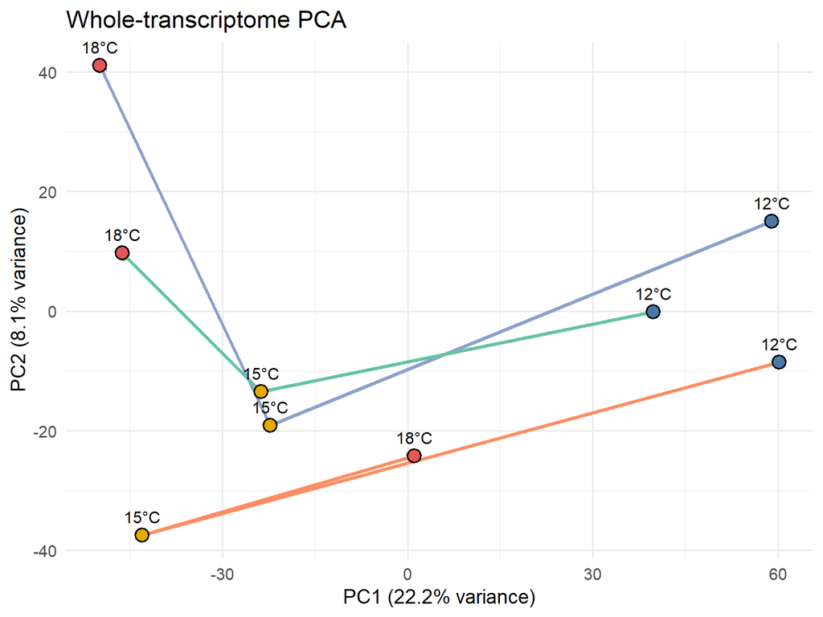

```r
knitr::kable(
  whole_transcriptome_results$distances,
  digits = 3,
  caption = "Whole-transcriptome trajectory distances in PCA space"
)
```

Whole-transcriptome trajectory distances in PCA space

| origin | Dist_12_15 | Dist_15_18 | Dist_12_18 | Ratio_15_18_to_12_15 |
| --- | --- | --- | --- | --- |
| W | 88.111 | 66.193 | 111.873 | 0.751 |
| H | 64.944 | 32.307 | 86.609 | 0.497 |
| S | 107.102 | 45.976 | 61.141 | 0.429 |

Whole-transcriptome trajectory analyses revealed contrasting transcriptomic responses among origins. Western fish exhibited progressive transcriptomic divergence across the temperature gradient, with the largest net displacement observed between 12°C and 18°C. Hybrid fish followed a broadly similar trajectory, showing continued divergence from the 12°C state, although the magnitude of change was smaller than in Western fish. In contrast, Southern fish displayed a distinct trajectory characterized by a large shift between 12°C and 15°C followed by movement back toward the 12°C transcriptomic state at 18°C. This pattern is consistent with downstream differential expression analyses, which identified evidence for a more transient transcriptional response in Southern fish.

## Tier 1 PCA

```r
tier1_results <-
  calculate_pca_trajectory(
    expr = expr_matrix[
      intersect(
        tier1_genes,
        rownames(expr_matrix)
      ),
    ],
    metadata = metadata,
    title_text = "Tier 1 PCA"
  )
```

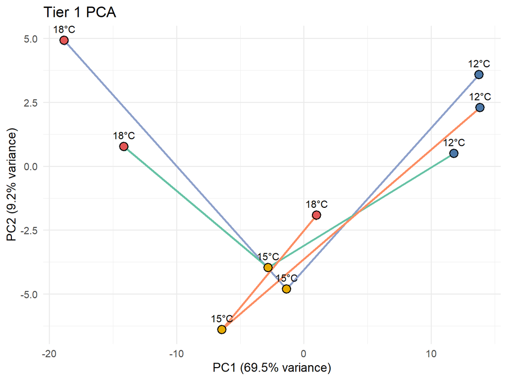

```r
knitr::kable(
  tier1_results$distances,
  digits = 3,
  caption = "Tier 1 trajectory distances in PCA space"
)
```

Tier 1 trajectory distances in PCA space

| origin | Dist_12_15 | Dist_15_18 | Dist_12_18 | Ratio_15_18_to_12_15 |
| --- | --- | --- | --- | --- |
| W | 17.275 | 19.989 | 32.594 | 1.157 |
| H | 15.240 | 12.291 | 25.917 | 0.806 |
| S | 22.051 | 8.675 | 13.509 | 0.393 |

Tier 1 trajectories broadly recapitulated the whole-transcriptome pattern, although separation among origins was reduced and the Southern trajectory exhibited a less pronounced return toward the 12°C state.

## Tier 2 PCA

```r
tier2_results <-
  calculate_pca_trajectory(
    expr = expr_matrix[
      intersect(
        tier2_genes,
        rownames(expr_matrix)
      ),
    ],
    metadata = metadata,
    title_text = "Tier 2 PCA"
  )
```

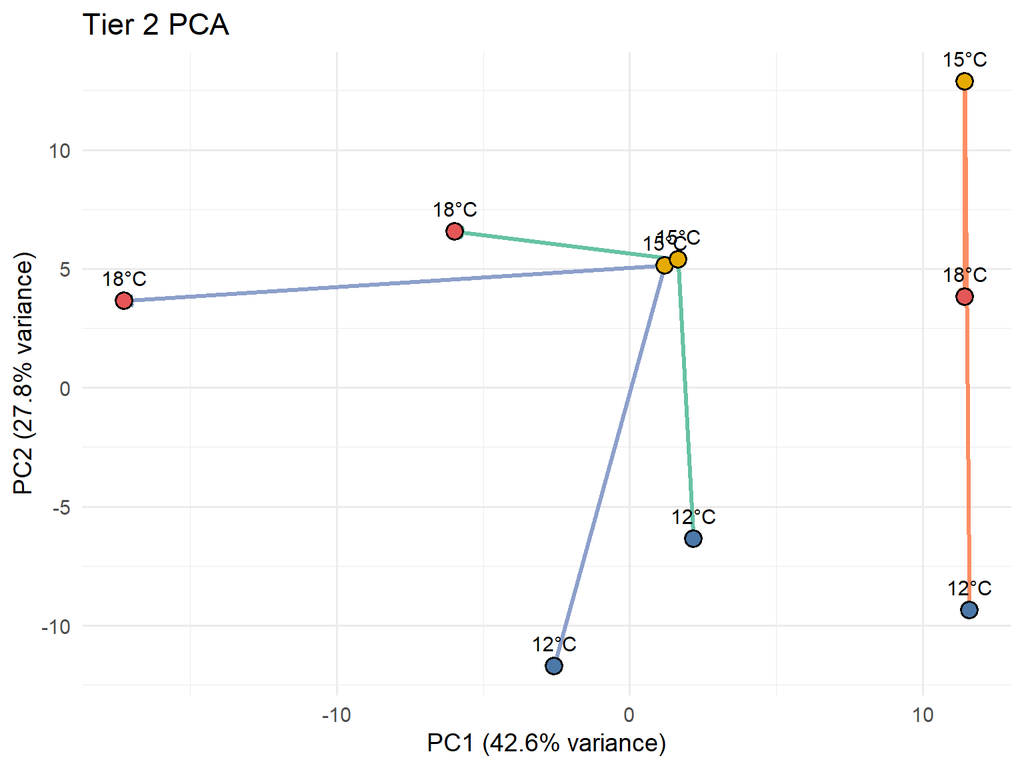

```r
knitr::kable(
  tier2_results$distances,
  digits = 3,
  caption = "Tier 2 trajectory distances in PCA space"
)
```

Tier 2 trajectory distances in PCA space

| origin | Dist_12_15 | Dist_15_18 | Dist_12_18 | Ratio_15_18_to_12_15 |
| --- | --- | --- | --- | --- |
| W | 17.263 | 18.511 | 21.234 | 1.072 |
| H | 11.760 | 7.705 | 15.278 | 0.655 |
| S | 22.223 | 9.072 | 13.152 | 0.408 |

[output not shown]

## Interaction genes PCA

```r
interaction_results <-
  calculate_pca_trajectory(
    expr = expr_matrix[
      intersect(
        interaction_genes,
        rownames(expr_matrix)
      ),
    ],
    metadata = metadata,
    title_text = "Interaction genes PCA"
  )
```

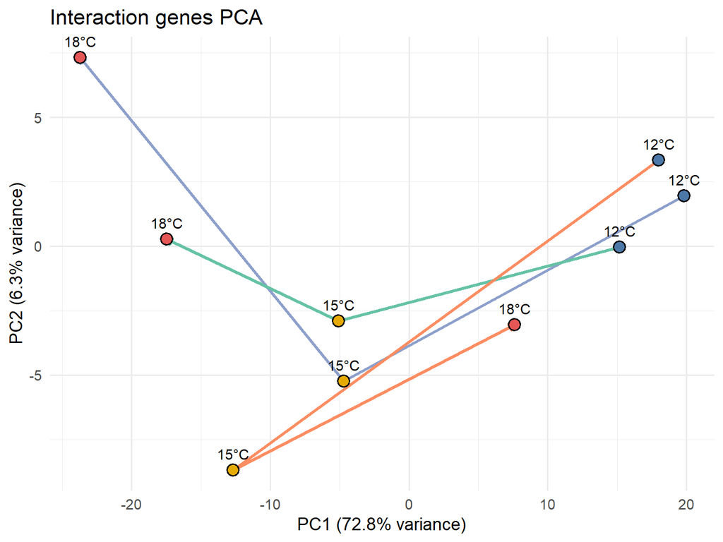

```r
knitr::kable(
  interaction_results$distances,
  digits = 3,
  caption = "Interaction-gene trajectory distances in PCA space"
)
```

Interaction-gene trajectory distances in PCA space

| origin | Dist_12_15 | Dist_15_18 | Dist_12_18 | Ratio_15_18_to_12_15 |
| --- | --- | --- | --- | --- |
| W | 25.571 | 22.784 | 43.869 | 0.891 |
| H | 20.456 | 12.811 | 32.671 | 0.626 |
| S | 32.971 | 21.085 | 12.192 | 0.640 |

Interaction genes retained evidence of a Southern trajectory reversal, although separation among origins was weaker than in the whole transcriptome.

## Tier 2b PCA

```r
tier2b_results <-
  calculate_pca_trajectory(
    expr = expr_matrix[
      intersect(
        tier2b_genes,
        rownames(expr_matrix)
      ),
    ],
    metadata = metadata,
    title_text = "Tier 2b PCA"
  )
```

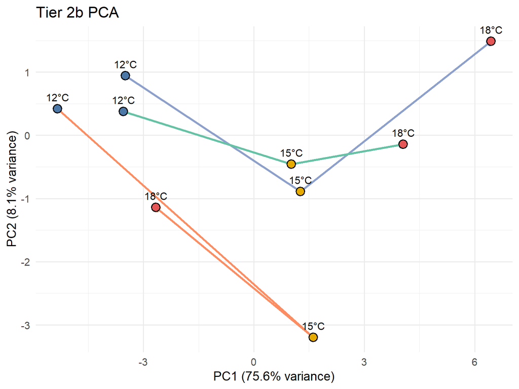

```r
knitr::kable(
  tier2b_results$distances,
  digits = 3,
  caption = "Tier 2b trajectory distances in PCA space"
)
```

Tier 2b trajectory distances in PCA space

| origin | Dist_12_15 | Dist_15_18 | Dist_12_18 | Ratio_15_18_to_12_15 |
| --- | --- | --- | --- | --- |
| W | 5.104 | 5.692 | 9.948 | 1.115 |
| H | 4.644 | 3.055 | 7.626 | 0.658 |
| S | 7.837 | 4.749 | 3.094 | 0.606 |

Tier 2b trajectories combined relatively strong separation among origins with a pronounced Southern trajectory reversal. Origin separation appeared greater than in the whole transcriptome but weaker than in Tier 2, consistent with Tier 2b representing a subset of Tier 2 population-divergence genes.

## Tier 3 misexpressed PCA

```r
tier3_results <-
  calculate_pca_trajectory(
    expr = expr_matrix[
      intersect(
        tier3_mis_genes,
        rownames(expr_matrix)
      ),
    ],
    metadata = metadata,
    title_text = "Tier 3 Misexpressed PCA"
  )
```

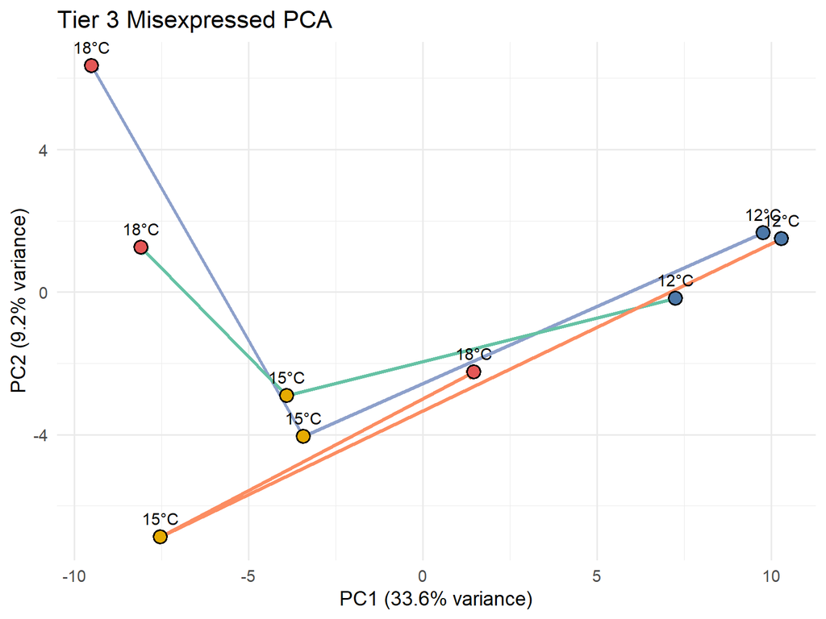

```r
knitr::kable(
  tier3_results$distances,
  digits = 3,
  caption = "Tier 3 misexpressed trajectory distances in PCA space"
)
```

Tier 3 misexpressed trajectory distances in PCA space

| origin | Dist_12_15 | Dist_15_18 | Dist_12_18 | Ratio_15_18_to_12_15 |
| --- | --- | --- | --- | --- |
| W | 14.372 | 12.053 | 19.830 | 0.839 |
| H | 11.478 | 5.914 | 15.406 | 0.515 |
| S | 19.685 | 10.118 | 9.580 | 0.514 |

Tier 3 trajectories showed substantial overlap among origins but retained a pronounced Southern trajectory reversal.

## Tier 1 ∩ Tier 3 Misexpressed PCA

```r
tier1_tier3_results <-
  calculate_pca_trajectory(
    expr = expr_matrix[
      intersect(
        tier1_tier3_mis_genes,
        rownames(expr_matrix)
      ),
    ],
    metadata = metadata,
    title_text = "Tier 1 ∩ Tier 3 Misexpressed PCA"
  )
```

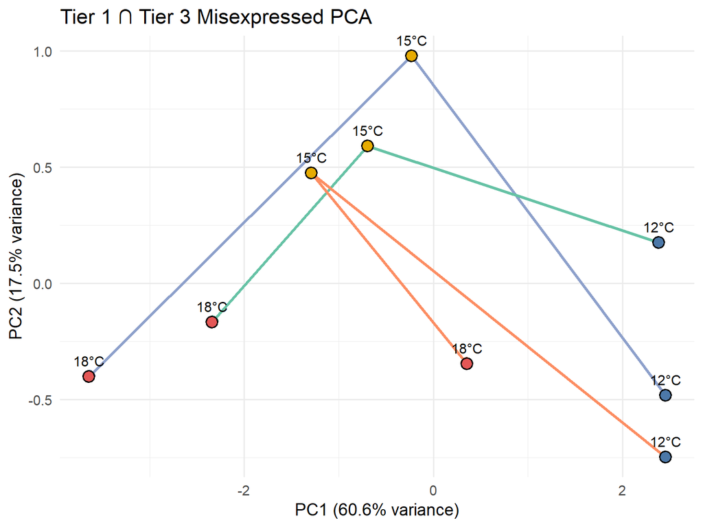

```r
knitr::kable(
  tier1_tier3_results$distances,
  digits = 3,
  caption = "Tier 1 ∩ Tier 3 misexpressed trajectory distances in PCA space"
)
```

Tier 1 ∩ Tier 3 misexpressed trajectory distances in PCA space

| origin | Dist_12_15 | Dist_15_18 | Dist_12_18 | Ratio_15_18_to_12_15 |
| --- | --- | --- | --- | --- |
| W | 3.058 | 3.679 | 6.098 | 1.203 |
| H | 3.106 | 1.812 | 4.737 | 0.583 |
| S | 3.939 | 1.840 | 2.136 | 0.467 |

The Tier 1 ∩ Tier 3 overlap exhibited a stronger Southern trajectory reversal than the broader Tier 1 gene set and more closely resembled the Tier 3 misexpressed gene set.

#### PCA TRAJECTORY GEOMETRY SUMMARY

```r
summarise_pca_trajectory <- function(result, dataset_name){

  # Variance explained
  var_exp <- round(
    100 * result$pca$sdev^2 / sum(result$pca$sdev^2),
    2
  )

  # PCA coordinates
  df <- result$plot_data

  geom <- df %>%
    group_by(origin) %>%
    summarise(
      x12 = PC1[temperature == 12],
      y12 = PC2[temperature == 12],
      x15 = PC1[temperature == 15],
      y15 = PC2[temperature == 15],
      x18 = PC1[temperature == 18],
      y18 = PC2[temperature == 18],
      .groups = "drop"
    ) %>%
    rowwise() %>%
    mutate(

      # trajectory vectors
      vx1 = x15 - x12,
      vy1 = y15 - y12,

      vx2 = x18 - x15,
      vy2 = y18 - y15,

      len1 = sqrt(vx1^2 + vy1^2),
      len2 = sqrt(vx2^2 + vy2^2),

      # angle between segments
      Angle_Degrees =
        acos(
          pmax(
            -1,
            pmin(
              1,
              (vx1 * vx2 + vy1 * vy2) /
                (len1 * len2)
            )
          )
        ) * 180 / pi,

      # net displacement
      Dist_12_18 =
        sqrt(
          (x18 - x12)^2 +
          (y18 - y12)^2
        ),

      # lower values indicate stronger return
      Return_Index =
        Dist_12_18 / len1
    ) %>%
    ungroup() %>%
    mutate(
      Dataset = dataset_name,
      PC1_Variance = var_exp[1],
      PC2_Variance = var_exp[2],
      PC1_PC2_Total = var_exp[1] + var_exp[2]
    ) %>%
    select(
      Dataset,
      origin,
      PC1_Variance,
      PC2_Variance,
      PC1_PC2_Total,
      Angle_Degrees,
      Dist_12_18,
      Return_Index
    )

  return(geom)
}

trajectory_summary <- bind_rows(

  summarise_pca_trajectory(
    whole_transcriptome_results,
    "Whole transcriptome"
  ),

  summarise_pca_trajectory(
    tier1_results,
    "Tier 1"
  ),

  summarise_pca_trajectory(
    tier2_results,
    "Tier 2"
  ),

  summarise_pca_trajectory(
    interaction_results,
    "Interaction genes"
  ),

  summarise_pca_trajectory(
    tier2b_results,
    "Tier 2b"
  ),

  summarise_pca_trajectory(
    tier3_results,
    "Tier 3 Misexpressed"
  ),

  summarise_pca_trajectory(
    tier1_tier3_results,
    "Tier1 ∩ Tier3 Misexpressed"
  )

)

knitr::kable(
  trajectory_summary,
  digits = 3,
  caption = "PCA trajectory geometry and variance summary"
)
```

PCA trajectory geometry and variance summary

| Dataset | origin | PC1_Variance | PC2_Variance | PC1_PC2_Total | Angle_Degrees | Dist_12_18 | Return_Index |
| --- | --- | --- | --- | --- | --- | --- | --- |
| Whole transcriptome | W | 22.23 | 8.12 | 30.35 | 88.179 | 111.873 | 1.270 |
| Whole transcriptome | H | 22.23 | 8.12 | 30.35 | 57.743 | 86.609 | 1.334 |
| Whole transcriptome | S | 22.23 | 8.12 | 30.35 | 178.933 | 61.141 | 0.571 |
| Tier 1 | W | 69.52 | 9.21 | 78.73 | 58.151 | 32.594 | 1.887 |
| Tier 1 | H | 69.52 | 9.21 | 78.73 | 39.660 | 25.917 | 1.701 |
| Tier 1 | S | 69.52 | 9.21 | 78.73 | 172.150 | 13.509 | 0.613 |
| Tier 2 | W | 42.61 | 27.76 | 70.37 | 107.273 | 21.234 | 1.230 |
| Tier 2 | H | 42.61 | 27.76 | 70.37 | 78.622 | 15.278 | 1.299 |
| Tier 2 | S | 42.61 | 27.76 | 70.37 | 179.563 | 13.152 | 0.592 |
| Interaction genes | W | 72.85 | 6.34 | 79.19 | 49.843 | 43.869 | 1.716 |
| Interaction genes | H | 72.85 | 6.34 | 79.19 | 22.318 | 32.671 | 1.597 |
| Interaction genes | S | 72.85 | 6.34 | 79.19 | 174.093 | 12.192 | 0.370 |
| Tier 2b | W | 75.65 | 8.06 | 83.71 | 45.784 | 9.948 | 1.949 |
| Tier 2b | H | 75.65 | 8.06 | 83.71 | 16.280 | 7.626 | 1.642 |
| Tier 2b | S | 75.65 | 8.06 | 83.71 | 178.193 | 3.094 | 0.395 |
| Tier 3 Misexpressed | W | 33.56 | 9.17 | 42.73 | 83.137 | 19.830 | 1.380 |
| Tier 3 Misexpressed | H | 33.56 | 9.17 | 42.73 | 58.649 | 15.406 | 1.342 |
| Tier 3 Misexpressed | S | 33.56 | 9.17 | 42.73 | 177.989 | 9.580 | 0.487 |
| Tier1 ∩ Tier3 Misexpressed | W | 60.60 | 17.48 | 78.08 | 50.545 | 6.098 | 1.994 |
| Tier1 ∩ Tier3 Misexpressed | H | 60.60 | 17.48 | 78.08 | 32.393 | 4.737 | 1.525 |
| Tier1 ∩ Tier3 Misexpressed | S | 60.60 | 17.48 | 78.08 | 171.559 | 2.136 | 0.542 |

The whole-transcriptome PCA revealed a distinct Southern transcriptional response to temperature, characterized by movement away from the 12°C transcriptomic state at 15°C followed by partial return toward the 12°C state at 18°C. This recovery pattern was also observed across all focal gene sets, indicating that it represents a pervasive feature of the Southern response to temperature. Hybrid trajectories generally resembled those of Western fish but exhibited reduced transcriptomic displacement across the temperature gradient. In addition, Tier 2 and Tier 2b gene sets exhibited visually distinct origin-specific trajectories, consistent with their definitions as genes showing population divergence between Southern and Western populations. The magnitude of the Southern trajectory reversal varied among gene sets and closely reflected their biological definitions. Tier 1 genes exhibited the weakest Southern trajectory reversal among all gene sets. Because Tier 1 genes were defined as conserved temperature-responsive transcripts shared across origins, this finding suggests that the Southern recovery pattern, although still clearly present, is less pronounced among genes contributing to the core thermal-response program shared between populations. Tier 2 population-divergence genes exhibited a Southern trajectory reversal similar to that observed across the whole transcriptome. Because these genes were identified based on differential expression between Southern and Western populations, the absence of a stronger reversal signal suggests that the Southern recovery pattern alone is unlikely to account for the differential expression observed between parental populations. In contrast, the strongest reversals were observed among interaction genes and Tier 2b local adaptation candidates. Because both gene sets were defined by origin-specific thermal responses, this pattern is consistent with the Southern recovery response representing a Southern-specific strategy for responding to temperature. Tier 3 misexpressed genes also exhibited relatively strong trajectory reversal, suggesting an association between the distinctive Southern recovery response and patterns of hybrid misexpression. The Tier 1 ∩ Tier 3 overlap exhibited a stronger Southern trajectory reversal than the broader Tier 1 gene set and more closely resembled the Tier 3 misexpressed gene set. This finding further supports an association between the Southern recovery response and hybrid misexpression.

```r
# ============================================================
# PCA GEOMETRY + VARIANCE SUMMARY FOR ALL TRAJECTORIES
# ============================================================

summarise_pca_trajectory <- function(result, dataset_name){

  # Variance explained
  var_exp <- round(
    100 * result$pca$sdev^2 / sum(result$pca$sdev^2),
    2
  )

  # PCA coordinates
  df <- result$plot_data

  geom <- df %>%
    group_by(origin) %>%
    summarise(
      x12 = PC1[temperature == 12],
      y12 = PC2[temperature == 12],
      x15 = PC1[temperature == 15],
      y15 = PC2[temperature == 15],
      x18 = PC1[temperature == 18],
      y18 = PC2[temperature == 18],
      .groups = "drop"
    ) %>%
    rowwise() %>%
    mutate(

      # trajectory vectors
      vx1 = x15 - x12,
      vy1 = y15 - y12,

      vx2 = x18 - x15,
      vy2 = y18 - y15,

      len1 = sqrt(vx1^2 + vy1^2),
      len2 = sqrt(vx2^2 + vy2^2),

      # angle between segments
      Angle_Degrees =
        acos(
          pmax(
            -1,
            pmin(
              1,
              (vx1 * vx2 + vy1 * vy2) /
                (len1 * len2)
            )
          )
        ) * 180 / pi,

      # distance remaining from start after full trajectory
      Dist_12_18 =
        sqrt(
          (x18 - x12)^2 +
          (y18 - y12)^2
        ),

      # how much return occurred
      Return_Index =
        Dist_12_18 / len1
    ) %>%
    ungroup() %>%
    mutate(
      Dataset = dataset_name,
      PC1_Variance = var_exp[1],
      PC2_Variance = var_exp[2],
      PC1_PC2_Total = var_exp[1] + var_exp[2]
    ) %>%
    select(
      Dataset,
      origin,
      PC1_Variance,
      PC2_Variance,
      PC1_PC2_Total,
      Angle_Degrees,
      Dist_12_18,
      Return_Index
    )

  return(geom)
}

# ============================================================
# RUN FOR ALL GENE SETS
# ============================================================

trajectory_summary <- bind_rows(

  summarise_pca_trajectory(
    whole_transcriptome_results,
    "Whole transcriptome"
  ),

  summarise_pca_trajectory(
    tier1_results,
    "Tier 1"
  ),

  summarise_pca_trajectory(
    tier2_results,
    "Tier 2"
  ),

  summarise_pca_trajectory(
    interaction_results,
    "Interaction genes"
  ),

  summarise_pca_trajectory(
    tier2b_results,
    "Tier 2b"
  ),

  summarise_pca_trajectory(
    tier3_results,
    "Tier 3 Misexpressed"
  ),

  summarise_pca_trajectory(
    tier1_tier3_results,
    "Tier1 ∩ Tier3 Misexpressed"
  )

)

knitr::kable(
  trajectory_summary,
  digits = 3,
  caption = "PCA trajectory geometry and variance summary"
)
```

PCA trajectory geometry and variance summary

| Dataset | origin | PC1_Variance | PC2_Variance | PC1_PC2_Total | Angle_Degrees | Dist_12_18 | Return_Index |
| --- | --- | --- | --- | --- | --- | --- | --- |
| Whole transcriptome | W | 22.23 | 8.12 | 30.35 | 88.179 | 111.873 | 1.270 |
| Whole transcriptome | H | 22.23 | 8.12 | 30.35 | 57.743 | 86.609 | 1.334 |
| Whole transcriptome | S | 22.23 | 8.12 | 30.35 | 178.933 | 61.141 | 0.571 |
| Tier 1 | W | 69.52 | 9.21 | 78.73 | 58.151 | 32.594 | 1.887 |
| Tier 1 | H | 69.52 | 9.21 | 78.73 | 39.660 | 25.917 | 1.701 |
| Tier 1 | S | 69.52 | 9.21 | 78.73 | 172.150 | 13.509 | 0.613 |
| Tier 2 | W | 42.61 | 27.76 | 70.37 | 107.273 | 21.234 | 1.230 |
| Tier 2 | H | 42.61 | 27.76 | 70.37 | 78.622 | 15.278 | 1.299 |
| Tier 2 | S | 42.61 | 27.76 | 70.37 | 179.563 | 13.152 | 0.592 |
| Interaction genes | W | 72.85 | 6.34 | 79.19 | 49.843 | 43.869 | 1.716 |
| Interaction genes | H | 72.85 | 6.34 | 79.19 | 22.318 | 32.671 | 1.597 |
| Interaction genes | S | 72.85 | 6.34 | 79.19 | 174.093 | 12.192 | 0.370 |
| Tier 2b | W | 75.65 | 8.06 | 83.71 | 45.784 | 9.948 | 1.949 |
| Tier 2b | H | 75.65 | 8.06 | 83.71 | 16.280 | 7.626 | 1.642 |
| Tier 2b | S | 75.65 | 8.06 | 83.71 | 178.193 | 3.094 | 0.395 |
| Tier 3 Misexpressed | W | 33.56 | 9.17 | 42.73 | 83.137 | 19.830 | 1.380 |
| Tier 3 Misexpressed | H | 33.56 | 9.17 | 42.73 | 58.649 | 15.406 | 1.342 |
| Tier 3 Misexpressed | S | 33.56 | 9.17 | 42.73 | 177.989 | 9.580 | 0.487 |
| Tier1 ∩ Tier3 Misexpressed | W | 60.60 | 17.48 | 78.08 | 50.545 | 6.098 | 1.994 |
| Tier1 ∩ Tier3 Misexpressed | H | 60.60 | 17.48 | 78.08 | 32.393 | 4.737 | 1.525 |
| Tier1 ∩ Tier3 Misexpressed | S | 60.60 | 17.48 | 78.08 | 171.559 | 2.136 | 0.542 |

## Gene expression trajectories

PCA trajectory analyses revealed broad differences in transcriptomic responses among gene sets, but PCA summarizes average patterns and cannot determine whether genes within a given set follow similar or distinct expression trajectories. To identify major classes of transcriptional responses, we performed unsupervised hierarchical clustering of gene-level expression profiles.

For each gene, mean VST expression was calculated for all origin-by-temperature combinations (W12, W15, W18, H12, H15, H18, S12, S15, and S18). Expression profiles were standardized on a per-gene basis to emphasize trajectory shape rather than absolute expression level. Genes were then clustered using hierarchical clustering with Ward’s linkage and Euclidean distance. Cluster numbers were evaluated using silhouette analysis and supplemented by visual inspection of cluster size and biological interpretability.

This analysis was performed separately for each focal gene set to determine whether different gene sets were characterized by distinct underlying response architectures.

### Helper functions for unsupervised clustering

```r
# ------------------------------------------------------------
# Build standardized trajectory matrix
# ------------------------------------------------------------

build_profile_matrix <- function(
    gene_set,
    expr_matrix,
    metadata
) {

  genes_present <- intersect(
    gene_set,
    rownames(expr_matrix)
  )

  profile_matrix <- lapply(

    genes_present,

    function(gene) {

      df <- data.frame(
        sample = colnames(expr_matrix),
        expression = as.numeric(expr_matrix[gene, ])
      ) %>%
        left_join(
          metadata,
          by = "sample"
        ) %>%
        group_by(
          origin,
          temperature
        ) %>%
        summarise(
          Mean = mean(expression),
          .groups = "drop"
        )

      data.frame(
        Gene = gene,

        W12 = df$Mean[df$origin == "W" & df$temperature == 12],
        W15 = df$Mean[df$origin == "W" & df$temperature == 15],
        W18 = df$Mean[df$origin == "W" & df$temperature == 18],

        H12 = df$Mean[df$origin == "H" & df$temperature == 12],
        H15 = df$Mean[df$origin == "H" & df$temperature == 15],
        H18 = df$Mean[df$origin == "H" & df$temperature == 18],

        S12 = df$Mean[df$origin == "S" & df$temperature == 12],
        S15 = df$Mean[df$origin == "S" & df$temperature == 15],
        S18 = df$Mean[df$origin == "S" & df$temperature == 18]
      )

    }

  ) %>%
    bind_rows()

  profile_scaled <- profile_matrix %>%
    column_to_rownames("Gene") %>%
    as.matrix()

  # Standardize each gene to emphasize profile shape
  profile_scaled <- t(
    scale(
      t(profile_scaled)
    )
  )

  return(profile_scaled)

}


# ------------------------------------------------------------
# Evaluate candidate cluster numbers
# ------------------------------------------------------------

evaluate_k <- function(
    profile_scaled,
    k_range = 2:12
) {

  hc <- hclust(
    dist(profile_scaled),
    method = "ward.D2"
  )

  bind_rows(

    lapply(

      k_range,

      function(k) {

        clusters <- cutree(
          hc,
          k = k
        )

        data.frame(
          k = k,

          Mean_Silhouette = mean(
            silhouette(
              clusters,
              dist(profile_scaled)
            )[, 3]
          ),

          N_Clusters = length(
            unique(clusters)
          ),

          Largest_Cluster = max(
            table(clusters)
          ),

          Smallest_Cluster = min(
            table(clusters)
          )
        )

      }

    )

  )

}


# ------------------------------------------------------------
# Run final clustering analysis
# ------------------------------------------------------------


run_clustering <- function(
    gene_set,
    expr_matrix,
    metadata,
    k
) {

  profile_scaled <- build_profile_matrix(
    gene_set,
    expr_matrix,
    metadata
  )

  hc <- hclust(
    dist(profile_scaled),
    method = "ward.D2"
  )

  clusters <- cutree(
    hc,
    k = k
  )

  cluster_sizes <- data.frame(
    Cluster = names(
      table(clusters)
    ),
    N_Genes = as.vector(
      table(clusters)
    )
  )

  cluster_profiles <- data.frame(
    profile_scaled,
    Cluster = factor(clusters)
  ) %>%
    rownames_to_column("Gene") %>%
    pivot_longer(
      cols = -c(Gene, Cluster),
      names_to = "Condition",
      values_to = "Expression"
    ) %>%
    mutate(
      Origin = substr(
        Condition,
        1,
        1
      ),
      Temp = factor(
        substr(
          Condition,
          2,
          3
        ),
        levels = c(
          "12",
          "15",
          "18"
        )
      )
    ) %>%
    group_by(
      Cluster,
      Origin,
      Temp
    ) %>%
    summarise(
      Mean = mean(Expression),
      .groups = "drop"
    )

  profile_table <- data.frame(
    profile_scaled,
    Cluster = factor(clusters)
  ) %>%
    group_by(Cluster) %>%
    summarise(
      across(
        where(is.numeric),
        mean
      ),
      .groups = "drop"
    )

  p <- ggplot(
    cluster_profiles,
    aes(
      x = Temp,
      y = Mean,
      colour = Origin,
      group = Origin
    )
  ) +
    geom_line(linewidth = 1.2) +
    geom_point(size = 2) +
    scale_colour_manual(
      values = origin_colors
    ) +
    facet_wrap(
      ~ Cluster,
      scales = "free_y"
    ) +
    labs(
      x = "Temperature (°C)",
      y = "Scaled expression",
      title = "Mean expression profiles recovered by unsupervised clustering"
    ) +
    theme_minimal(
      base_size = 14
    )

  return(
    list(
      profile_scaled = profile_scaled,
      hclust = hc,
      clusters = clusters,
      cluster_sizes = cluster_sizes,
      cluster_profiles = cluster_profiles,
      profile_table = profile_table,
      plot = p
    )
  )

}



# ============================================================
# Compare multiple clustering solutions
# ============================================================

explore_clusters <- function(
    gene_set,
    expr_matrix,
    metadata,
    k_values = 2:5
){

  results <- list()

  for(k in k_values){

    cat("\n")
    cat("========================================\n")
    cat("k =", k, "\n")
    cat("========================================\n")

    res <- run_clustering(
      gene_set = gene_set,
      expr_matrix = expr_matrix,
      metadata = metadata,
      k = k
    )

    print(res$plot)

    print(
      knitr::kable(
        res$cluster_sizes,
        caption = paste(
          "Cluster sizes for k =",
          k
        )
      )
    )

    print(
      knitr::kable(
        res$profile_table,
        digits = 2,
        caption = paste(
          "Cluster profiles for k =",
          k
        )
      )
    )

    results[[paste0("k_", k)]] <- res
  }

  return(results)

}
```

### Tier 1

```r
tier1_k <- evaluate_k(
  build_profile_matrix(
    tier1_genes,
    expr_matrix,
    metadata
  )
)

knitr::kable(
  tier1_k,
  digits = 3
)
```

| k | Mean_Silhouette | N_Clusters | Largest_Cluster | Smallest_Cluster |
| --- | --- | --- | --- | --- |
| 2 | 0.658 | 2 | 324 | 269 |
| 3 | 0.617 | 3 | 269 | 97 |
| 4 | 0.560 | 4 | 241 | 28 |
| 5 | 0.560 | 5 | 235 | 6 |
| 6 | 0.418 | 6 | 235 | 6 |
| 7 | 0.283 | 7 | 145 | 6 |
| 8 | 0.286 | 8 | 145 | 6 |
| 9 | 0.234 | 9 | 145 | 6 |
| 10 | 0.234 | 10 | 145 | 6 |
| 11 | 0.199 | 11 | 145 | 6 |
| 12 | 0.168 | 12 | 113 | 6 |

```r
tier1_explore <- explore_clusters(
  gene_set = tier1_genes,
  expr_matrix = expr_matrix,
  metadata = metadata,
  k_values = c(2,3,4,5)
)
```

```
##
## ========================================
## k = 2
## ========================================
```

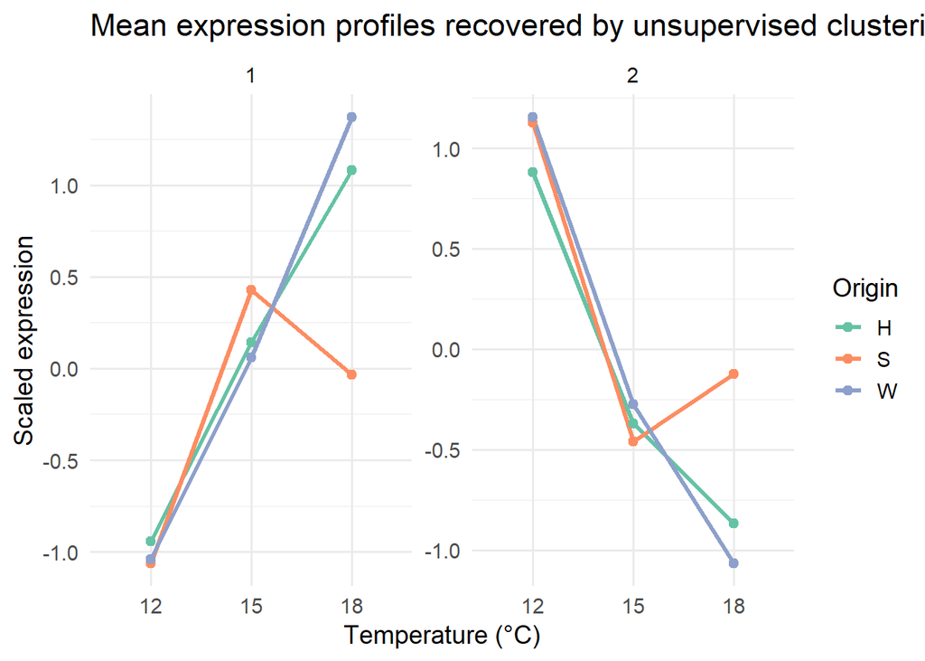

```
##
##
## Table: Cluster sizes for k = 2
##
## |Cluster | N_Genes|
## |:-------|-------:|
## |1       |     269|
## |2       |     324|
##
##
## Table: Cluster profiles for k = 2
##
## |Cluster |   W12|   W15|   W18|   H12|   H15|   H18|   S12|   S15|   S18|
## |:-------|-----:|-----:|-----:|-----:|-----:|-----:|-----:|-----:|-----:|
## |1       | -1.04|  0.06|  1.37| -0.94|  0.14|  1.08| -1.06|  0.43| -0.03|
## |2       |  1.15| -0.27| -1.07|  0.88| -0.37| -0.87|  1.13| -0.46| -0.12|
##
## ========================================
## k = 3
## ========================================
```

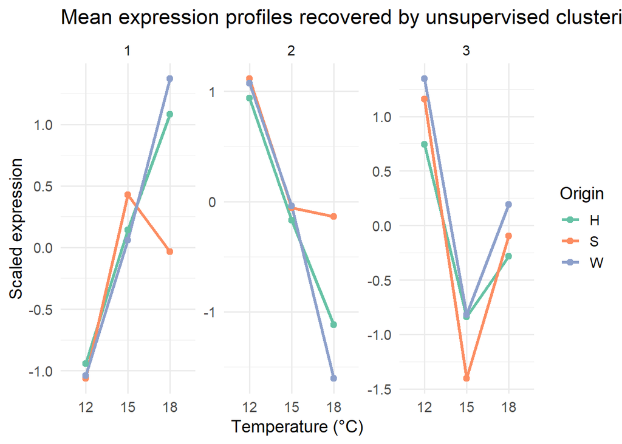

```
##
##
## Table: Cluster sizes for k = 3
##
## |Cluster | N_Genes|
## |:-------|-------:|
## |1       |     269|
## |2       |     227|
## |3       |      97|
##
##
## Table: Cluster profiles for k = 3
##
## |Cluster |   W12|   W15|   W18|   H12|   H15|   H18|   S12|   S15|   S18|
## |:-------|-----:|-----:|-----:|-----:|-----:|-----:|-----:|-----:|-----:|
## |1       | -1.04|  0.06|  1.37| -0.94|  0.14|  1.08| -1.06|  0.43| -0.03|
## |2       |  1.07| -0.04| -1.60|  0.94| -0.17| -1.12|  1.12| -0.06| -0.14|
## |3       |  1.35| -0.82|  0.19|  0.74| -0.84| -0.28|  1.16| -1.40| -0.10|
##
## ========================================
## k = 4
## ========================================
```

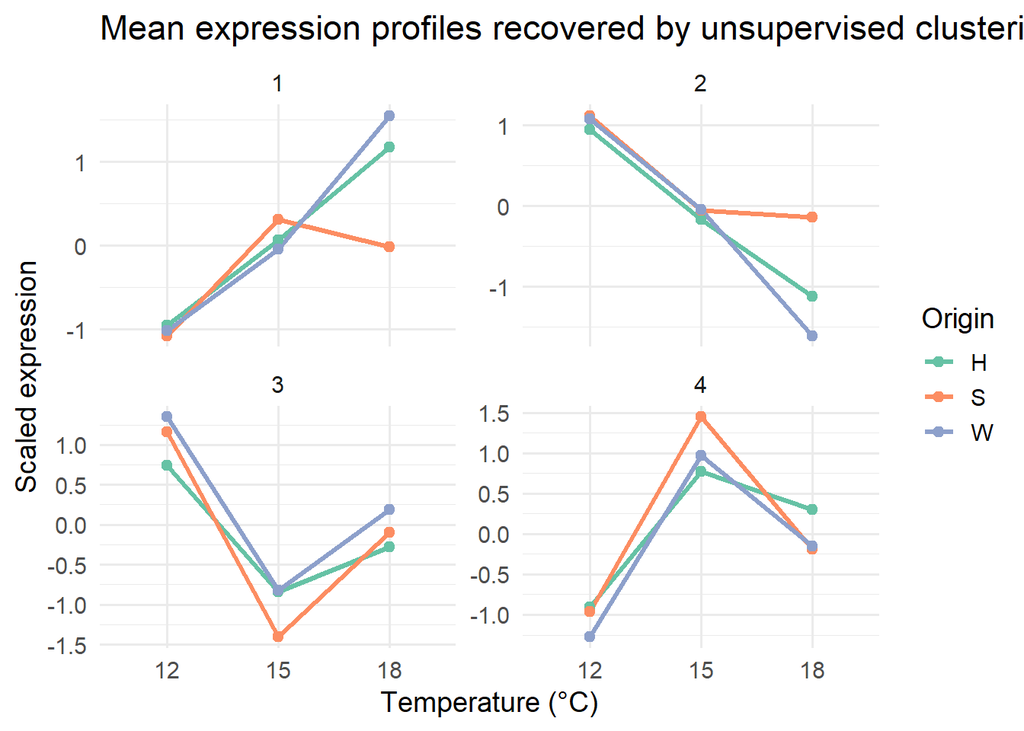

```
##
##
## Table: Cluster sizes for k = 4
##
## |Cluster | N_Genes|
## |:-------|-------:|
## |1       |     241|
## |2       |     227|
## |3       |      97|
## |4       |      28|
##
##
## Table: Cluster profiles for k = 4
##
## |Cluster |   W12|   W15|   W18|   H12|   H15|   H18|   S12|   S15|   S18|
## |:-------|-----:|-----:|-----:|-----:|-----:|-----:|-----:|-----:|-----:|
## |1       | -1.02| -0.05|  1.55| -0.95|  0.07|  1.17| -1.08|  0.31| -0.01|
## |2       |  1.07| -0.04| -1.60|  0.94| -0.17| -1.12|  1.12| -0.06| -0.14|
## |3       |  1.35| -0.82|  0.19|  0.74| -0.84| -0.28|  1.16| -1.40| -0.10|
## |4       | -1.27|  0.97| -0.15| -0.90|  0.77|  0.30| -0.97|  1.45| -0.19|
##
## ========================================
## k = 5
## ========================================
```

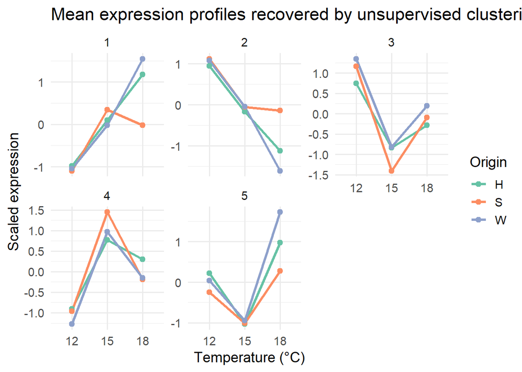

```
##
##
## Table: Cluster sizes for k = 5
##
## |Cluster | N_Genes|
## |:-------|-------:|
## |1       |     235|
## |2       |     227|
## |3       |      97|
## |4       |      28|
## |5       |       6|
##
##
## Table: Cluster profiles for k = 5
##
## |Cluster |   W12|   W15|   W18|   H12|   H15|   H18|   S12|   S15|   S18|
## |:-------|-----:|-----:|-----:|-----:|-----:|-----:|-----:|-----:|-----:|
## |1       | -1.04| -0.02|  1.54| -0.98|  0.10|  1.18| -1.10|  0.34| -0.02|
## |2       |  1.07| -0.04| -1.60|  0.94| -0.17| -1.12|  1.12| -0.06| -0.14|
## |3       |  1.35| -0.82|  0.19|  0.74| -0.84| -0.28|  1.16| -1.40| -0.10|
## |4       | -1.27|  0.97| -0.15| -0.90|  0.77|  0.30| -0.97|  1.45| -0.19|
## |5       |  0.03| -0.95|  1.72|  0.22| -1.03|  0.98| -0.25| -1.01|  0.28|
```

Hierarchical clustering of Tier 1 genes identified k = 2 as the statistically optimal solution based on silhouette width (0.658). However, the k = 4 solution recovered four biologically distinct trajectory classes while retaining reasonably large cluster sizes. In addition to progressive increases, progressive decreases, and transient valley responses identified at lower k values, the k = 4 solution recovered a distinct transient peak trajectory that was not resolved at k = 3. Increasing clustering to k = 5 primarily subdivided an existing trajectory class into smaller groups without identifying a novel response pattern. We therefore retained k = 4 as the most biologically informative clustering solution.

Cluster 1 (241 genes)

West: progressive increase Hybrid: progressive increase (reduced magnitude) South: weak transient peak

Cluster 2 (227 genes)

West: progressive decrease Hybrid: progressive decrease (weaker magnitude) South: response attenuation at 18°C

Cluster 3 (97 genes)

West: transient valley Hybrid: transient valley (weakest magnitude) South: transient valley (strongest magnitude)

Cluster 4 (28 genes)

West: transient peak Hybrid: transient peak (weakest magnitude) South: transient peak (strongest magnitude)

Tier 1 conserved temperature-responsive genes were resolved into four major transcriptional response classes. The two largest clusters differentiated Southern fish from Western and Hybrid fish, with Southern fish exhibiting more pronounced non-linear responses, whereas hybrid trajectories generally resembled those of Western fish but with reduced response magnitudes. The two smaller clusters recovered shared transient peak and transient valley responses across all origins, with response magnitudes consistently strongest in Southern fish and weakest in hybrids.

### Tier 2

```r
tier2_k <- evaluate_k(
  build_profile_matrix(
    tier2_genes,
    expr_matrix,
    metadata
  )
)

knitr::kable(
  tier2_k,
  digits = 3
)
```

| k | Mean_Silhouette | N_Clusters | Largest_Cluster | Smallest_Cluster |
| --- | --- | --- | --- | --- |
| 2 | 0.522 | 2 | 831 | 667 |
| 3 | 0.447 | 3 | 831 | 300 |
| 4 | 0.354 | 4 | 425 | 300 |
| 5 | 0.326 | 5 | 425 | 105 |
| 6 | 0.265 | 6 | 425 | 105 |
| 7 | 0.219 | 7 | 367 | 105 |
| 8 | 0.204 | 8 | 367 | 59 |
| 9 | 0.156 | 9 | 293 | 59 |
| 10 | 0.144 | 10 | 293 | 59 |
| 11 | 0.146 | 11 | 293 | 15 |
| 12 | 0.142 | 12 | 293 | 15 |

```r
tier2_explore <- explore_clusters(
  gene_set = tier2_genes,
  expr_matrix = expr_matrix,
  metadata = metadata,
  k_values = c(2,3,4,5)
)
```

```
##
## ========================================
## k = 2
## ========================================
```

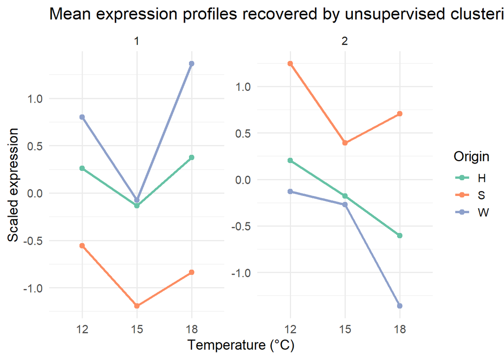

```
##
##
## Table: Cluster sizes for k = 2
##
## |Cluster | N_Genes|
## |:-------|-------:|
## |1       |     831|
## |2       |     667|
##
##
## Table: Cluster profiles for k = 2
##
## |Cluster |   W12|   W15|   W18|  H12|   H15|   H18|   S12|   S15|   S18|
## |:-------|-----:|-----:|-----:|----:|-----:|-----:|-----:|-----:|-----:|
## |1       |  0.80| -0.08|  1.37| 0.26| -0.14|  0.38| -0.56| -1.19| -0.84|
## |2       | -0.13| -0.27| -1.36| 0.20| -0.18| -0.61|  1.25|  0.39|  0.71|
##
## ========================================
## k = 3
## ========================================
```

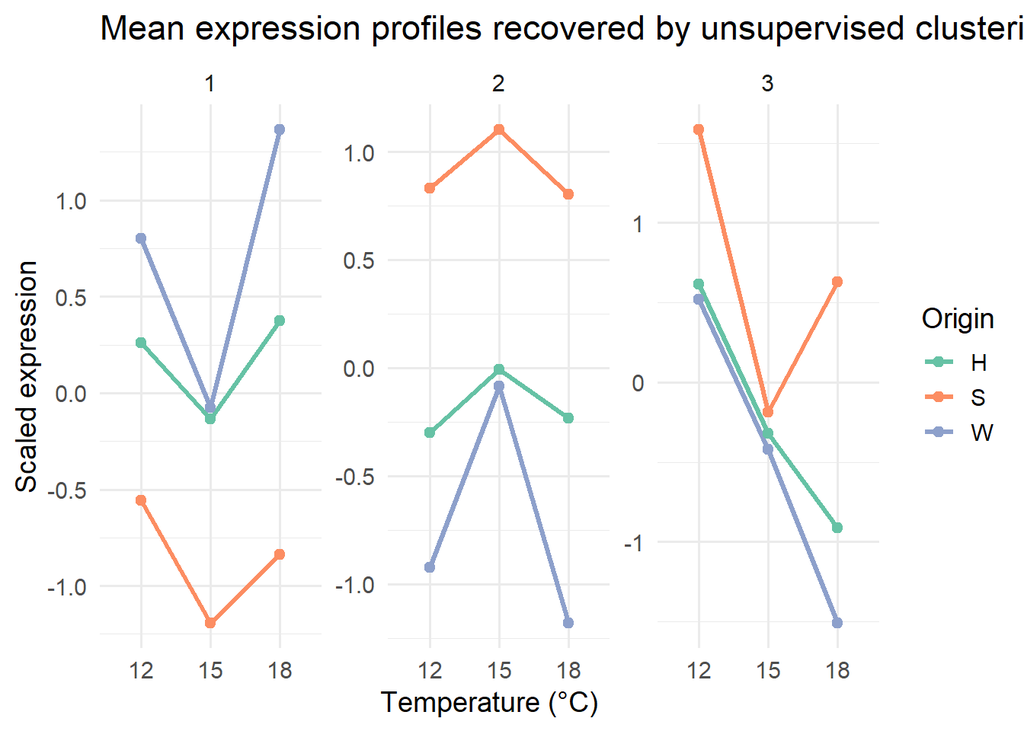

```
##
##
## Table: Cluster sizes for k = 3
##
## |Cluster | N_Genes|
## |:-------|-------:|
## |1       |     831|
## |2       |     300|
## |3       |     367|
##
##
## Table: Cluster profiles for k = 3
##
## |Cluster |   W12|   W15|   W18|   H12|   H15|   H18|   S12|   S15|   S18|
## |:-------|-----:|-----:|-----:|-----:|-----:|-----:|-----:|-----:|-----:|
## |1       |  0.80| -0.08|  1.37|  0.26| -0.14|  0.38| -0.56| -1.19| -0.84|
## |2       | -0.92| -0.09| -1.18| -0.30| -0.01| -0.23|  0.83|  1.10|  0.80|
## |3       |  0.52| -0.42| -1.51|  0.62| -0.32| -0.91|  1.58| -0.19|  0.63|
##
## ========================================
## k = 4
## ========================================
```

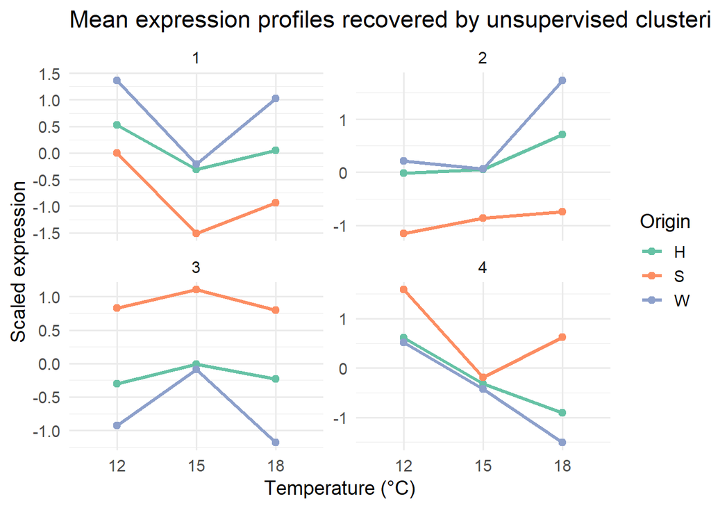

```
##
##
## Table: Cluster sizes for k = 4
##
## |Cluster | N_Genes|
## |:-------|-------:|
## |1       |     425|
## |2       |     406|
## |3       |     300|
## |4       |     367|
##
##
## Table: Cluster profiles for k = 4
##
## |Cluster |   W12|   W15|   W18|   H12|   H15|   H18|   S12|   S15|   S18|
## |:-------|-----:|-----:|-----:|-----:|-----:|-----:|-----:|-----:|-----:|
## |1       |  1.36| -0.21|  1.02|  0.52| -0.31|  0.05|  0.00| -1.51| -0.93|
## |2       |  0.22|  0.06|  1.73| -0.02|  0.05|  0.72| -1.15| -0.86| -0.74|
## |3       | -0.92| -0.09| -1.18| -0.30| -0.01| -0.23|  0.83|  1.10|  0.80|
## |4       |  0.52| -0.42| -1.51|  0.62| -0.32| -0.91|  1.58| -0.19|  0.63|
##
## ========================================
## k = 5
## ========================================
```

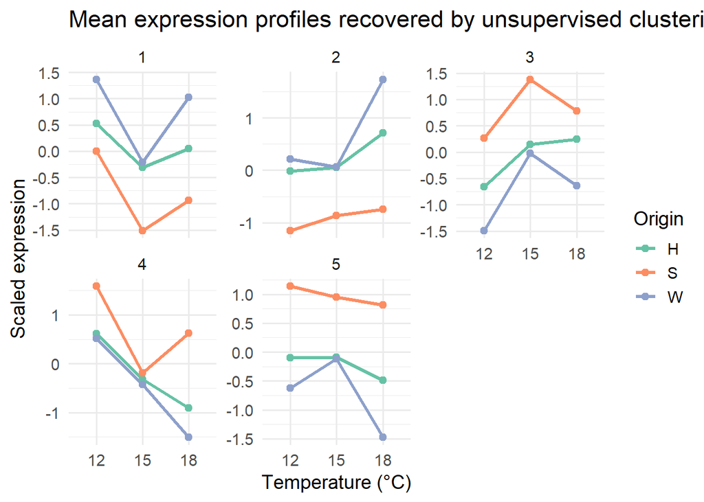

```
##
##
## Table: Cluster sizes for k = 5
##
## |Cluster | N_Genes|
## |:-------|-------:|
## |1       |     425|
## |2       |     406|
## |3       |     105|
## |4       |     367|
## |5       |     195|
##
##
## Table: Cluster profiles for k = 5
##
## |Cluster |   W12|   W15|   W18|   H12|   H15|   H18|   S12|   S15|   S18|
## |:-------|-----:|-----:|-----:|-----:|-----:|-----:|-----:|-----:|-----:|
## |1       |  1.36| -0.21|  1.02|  0.52| -0.31|  0.05|  0.00| -1.51| -0.93|
## |2       |  0.22|  0.06|  1.73| -0.02|  0.05|  0.72| -1.15| -0.86| -0.74|
## |3       | -1.49| -0.02| -0.64| -0.66|  0.15|  0.25|  0.26|  1.38|  0.78|
## |4       |  0.52| -0.42| -1.51|  0.62| -0.32| -0.91|  1.58| -0.19|  0.63|
## |5       | -0.62| -0.12| -1.47| -0.10| -0.09| -0.49|  1.14|  0.95|  0.81|
```

Hierarchical clustering of Tier 2 genes identified k = 2 (831 and 667 genes) as the statistically optimal solution based on silhouette width (0.522). Higher-order clustering solutions resulted in progressively lower silhouette widths, indicating weaker clustering structure within this large and heterogeneous set of population-divergence genes. We therefore retained k = 2 as the most parsimonious and statistically supported clustering solution.

Cluster 1 (831 genes)

West: transient valley Hybrid: transient valley (weakest magnitude) South: transient valley with reduced expression relative to West and Hybrid

Cluster 2 (667 genes)

West: progressive decrease Hybrid: progressive decrease (reduced magnitude) South: weak transient valley with elevated expression relative to West and Hybrid

Tier 2 population-divergence genes were resolved into two broad trajectory classes. The largest cluster recovered a shared transient valley response across all origins, with Southern fish exhibiting lower expression and hybrids showing the weakest response magnitude. In contrast, the second cluster differentiated Southern fish from Western and Hybrid fish through trajectory shape, with Southern fish exhibiting a weak transient valley response and higher expression levels, whereas Western and Hybrid fish displayed progressive decreases, with hybrids again showing reduced response magnitudes. In both clusters, hybrid expression profiles were generally intermediate between the parental populations, whereas Southern fish exhibited either reduced or elevated expression relative to Western and Hybrid fish across the temperature gradient. These results indicate that population divergence can arise through both differences in expression level despite similar response trajectories and differences in the trajectory of the transcriptional response itself.

### Interaction genes

```r
interaction_k <- evaluate_k(
  build_profile_matrix(
    interaction_genes,
    expr_matrix,
    metadata
  )
)

knitr::kable(
  interaction_k,
  digits = 3
)
```

| k | Mean_Silhouette | N_Clusters | Largest_Cluster | Smallest_Cluster |
| --- | --- | --- | --- | --- |
| 2 | 0.589 | 2 | 716 | 261 |
| 3 | 0.526 | 3 | 716 | 102 |
| 4 | 0.232 | 4 | 390 | 102 |
| 5 | 0.243 | 5 | 340 | 50 |
| 6 | 0.236 | 6 | 340 | 30 |
| 7 | 0.217 | 7 | 326 | 30 |
| 8 | 0.219 | 8 | 326 | 29 |
| 9 | 0.223 | 9 | 326 | 15 |
| 10 | 0.190 | 10 | 326 | 15 |
| 11 | 0.189 | 11 | 326 | 15 |
| 12 | 0.149 | 12 | 226 | 15 |

```r
interaction_explore <- explore_clusters(
  gene_set = interaction_genes,
  expr_matrix = expr_matrix,
  metadata = metadata,
  k_values = c(2,3,4)
)
```

```
##
## ========================================
## k = 2
## ========================================
```

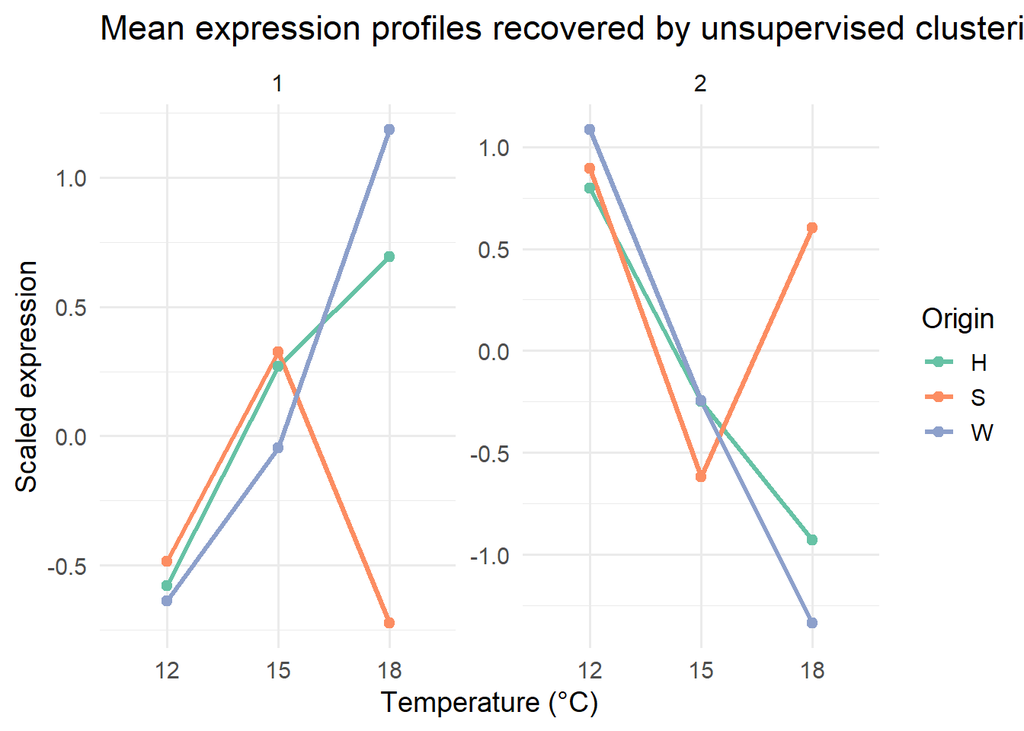

```
##
##
## Table: Cluster sizes for k = 2
##
## |Cluster | N_Genes|
## |:-------|-------:|
## |1       |     261|
## |2       |     716|
##
##
## Table: Cluster profiles for k = 2
##
## |Cluster |   W12|   W15|   W18|   H12|   H15|   H18|   S12|   S15|   S18|
## |:-------|-----:|-----:|-----:|-----:|-----:|-----:|-----:|-----:|-----:|
## |1       | -0.64| -0.05|  1.19| -0.58|  0.27|  0.69| -0.49|  0.32| -0.72|
## |2       |  1.09| -0.24| -1.34|  0.80| -0.25| -0.93|  0.90| -0.62|  0.60|
##
## ========================================
## k = 3
## ========================================
```

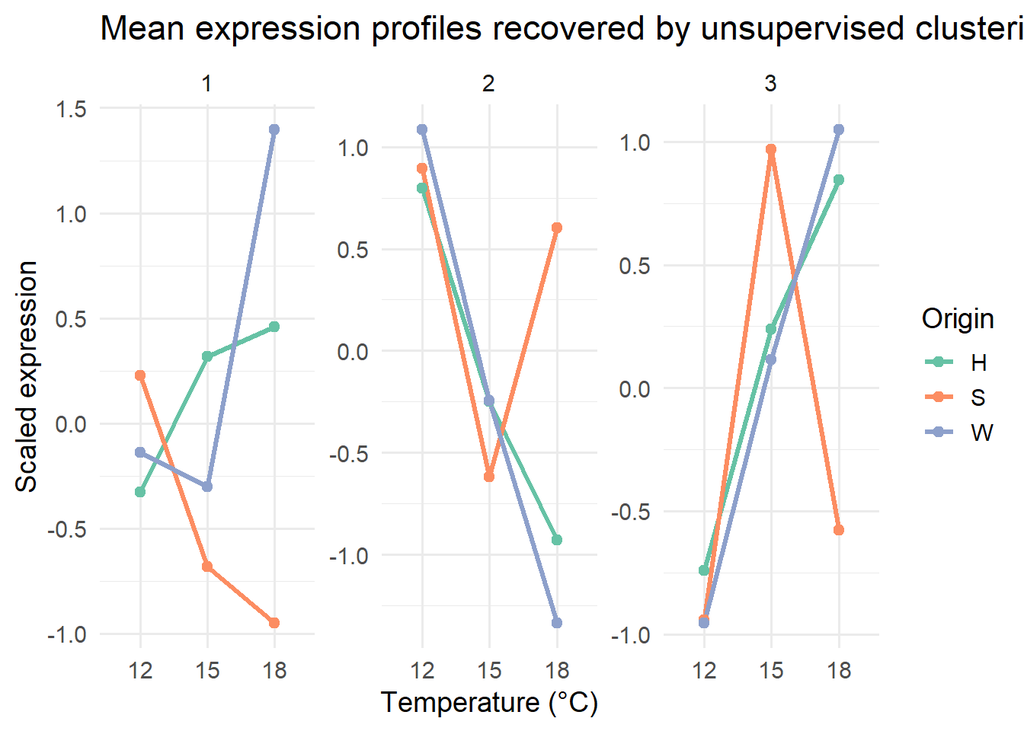

```
##
##
## Table: Cluster sizes for k = 3
##
## |Cluster | N_Genes|
## |:-------|-------:|
## |1       |     102|
## |2       |     716|
## |3       |     159|
##
##
## Table: Cluster profiles for k = 3
##
## |Cluster |   W12|   W15|   W18|   H12|   H15|   H18|   S12|   S15|   S18|
## |:-------|-----:|-----:|-----:|-----:|-----:|-----:|-----:|-----:|-----:|
## |1       | -0.14| -0.30|  1.40| -0.33|  0.32|  0.46|  0.23| -0.68| -0.95|
## |2       |  1.09| -0.24| -1.34|  0.80| -0.25| -0.93|  0.90| -0.62|  0.60|
## |3       | -0.95|  0.12|  1.05| -0.74|  0.24|  0.84| -0.94|  0.97| -0.58|
##
## ========================================
## k = 4
## ========================================
```

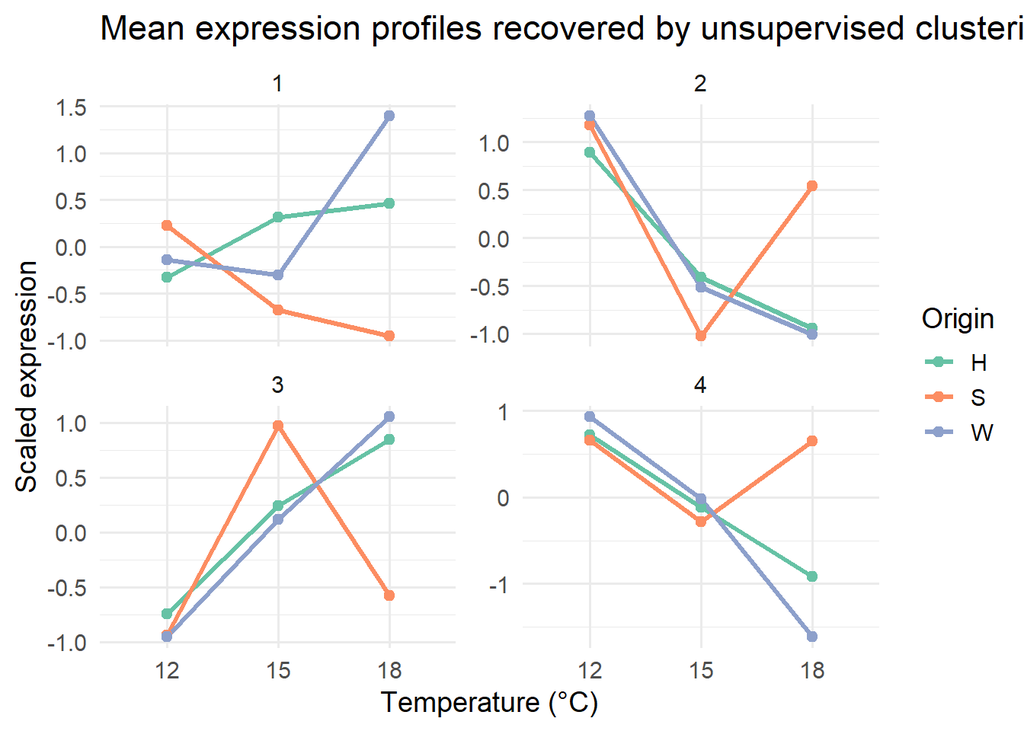

```
##
##
## Table: Cluster sizes for k = 4
##
## |Cluster | N_Genes|
## |:-------|-------:|
## |1       |     102|
## |2       |     326|
## |3       |     159|
## |4       |     390|
##
##
## Table: Cluster profiles for k = 4
##
## |Cluster |   W12|   W15|   W18|   H12|   H15|   H18|   S12|   S15|   S18|
## |:-------|-----:|-----:|-----:|-----:|-----:|-----:|-----:|-----:|-----:|
## |1       | -0.14| -0.30|  1.40| -0.33|  0.32|  0.46|  0.23| -0.68| -0.95|
## |2       |  1.27| -0.51| -1.01|  0.89| -0.41| -0.94|  1.18| -1.02|  0.54|
## |3       | -0.95|  0.12|  1.05| -0.74|  0.24|  0.84| -0.94|  0.97| -0.58|
## |4       |  0.93| -0.02| -1.61|  0.72| -0.12| -0.92|  0.66| -0.29|  0.65|
```

Silhouette widths remained high for both k = 2 (0.589) and k = 3 (0.526), indicating reasonable clustering structure. The k = 3 solution recovered an additional biologically interpretable trajectory relative to k = 2 while retaining strong clustering support. In contrast, clustering solutions beyond k = 3 resulted in a substantial decline in silhouette width, indicating limited support for further subdivision. We therefore retained k = 3 as the most biologically informative clustering solution.

Cluster 1 (102 genes)

West: transient valley Hybrid: progressive increase South: progressive decrease

Cluster 2 (716 genes)

West: progressive decrease Hybrid: progressive decrease (reduced magnitude) South: transient valley

Cluster 3 (159 genes)

West: progressive increase Hybrid: progressive increase (reduced magnitude) South: transient peak

The majority of interaction genes (Clusters 2 and 3; 875 genes) exhibited similar trajectories in Western and Hybrid fish, with hybrids generally showing reduced response magnitudes relative to Western fish. In contrast, Southern fish displayed non-linear transcriptional responses characterized by pronounced shifts at 15°C followed by partial recovery at 18°C. This pattern is consistent with the recovery signal observed in the PCA, where Southern fish exhibited the largest transcriptional shift between 12°C and 15°C but a substantially smaller separation between 12°C and 18°C.

Cluster 1 (102 genes) exhibited a distinct response pattern in which Western, Hybrid, and Southern fish followed different expression trajectories. Notably, hybrids displayed a progressive increase with temperature, whereas Southern fish showed a progressive decrease and Western fish exhibited a transient valley response. This cluster therefore represents a subset of genes with expression patterns that diverge from both parental response trajectories and may reflect novel regulatory responses in hybrids.

### Tier 2b

#### Evaluate clustering support across k values

```r
# Evaluate clustering solutions
tier2b_k <- evaluate_k(
  build_profile_matrix(
    tier2b_genes,
    expr_matrix,
    metadata
  )
)

knitr::kable(
  tier2b_k,
  digits = 3
)
```

| k | Mean_Silhouette | N_Clusters | Largest_Cluster | Smallest_Cluster |
| --- | --- | --- | --- | --- |
| 2 | 0.663 | 2 | 38 | 7 |
| 3 | 0.494 | 3 | 30 | 7 |
| 4 | 0.461 | 4 | 30 | 2 |
| 5 | 0.465 | 5 | 30 | 1 |
| 6 | 0.289 | 6 | 19 | 1 |
| 7 | 0.252 | 7 | 19 | 1 |
| 8 | 0.255 | 8 | 19 | 1 |
| 9 | 0.255 | 9 | 19 | 1 |
| 10 | 0.213 | 10 | 12 | 1 |
| 11 | 0.202 | 11 | 12 | 1 |
| 12 | 0.216 | 12 | 11 | 1 |

```r
# Explore clustering solutions
tier2b_explore <- explore_clusters(
  gene_set = tier2b_genes,
  expr_matrix = expr_matrix,
  metadata = metadata,
  k_values = c(2, 3, 4, 5, 6)
)
```

```
##
## ========================================
## k = 2
## ========================================
```

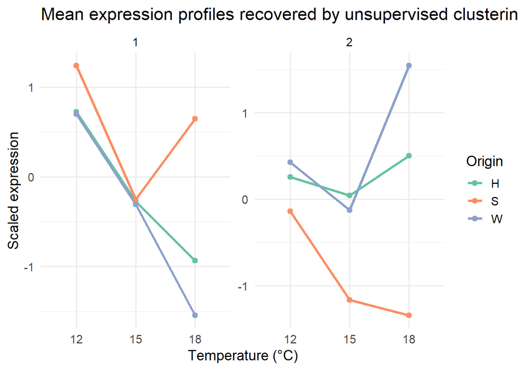

```
##
##
## Table: Cluster sizes for k = 2
##
## |Cluster | N_Genes|
## |:-------|-------:|
## |1       |      38|
## |2       |       7|
##
##
## Table: Cluster profiles for k = 2
##
## |Cluster |  W12|   W15|   W18|  H12|   H15|   H18|   S12|   S15|   S18|
## |:-------|----:|-----:|-----:|----:|-----:|-----:|-----:|-----:|-----:|
## |1       | 0.70| -0.31| -1.54| 0.72| -0.27| -0.93|  1.24| -0.25|  0.64|
## |2       | 0.43| -0.12|  1.55| 0.26|  0.04|  0.50| -0.14| -1.16| -1.34|
##
## ========================================
## k = 3
## ========================================
```

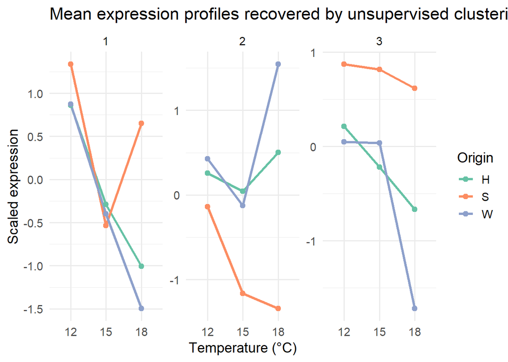

```
##
##
## Table: Cluster sizes for k = 3
##
## |Cluster | N_Genes|
## |:-------|-------:|
## |1       |      30|
## |2       |       7|
## |3       |       8|
##
##
## Table: Cluster profiles for k = 3
##
## |Cluster |  W12|   W15|   W18|  H12|   H15|   H18|   S12|   S15|   S18|
## |:-------|----:|-----:|-----:|----:|-----:|-----:|-----:|-----:|-----:|
## |1       | 0.87| -0.40| -1.50| 0.86| -0.29| -1.01|  1.34| -0.53|  0.65|
## |2       | 0.43| -0.12|  1.55| 0.26|  0.04|  0.50| -0.14| -1.16| -1.34|
## |3       | 0.05|  0.04| -1.72| 0.21| -0.22| -0.67|  0.87|  0.82|  0.62|
##
## ========================================
## k = 4
## ========================================
```

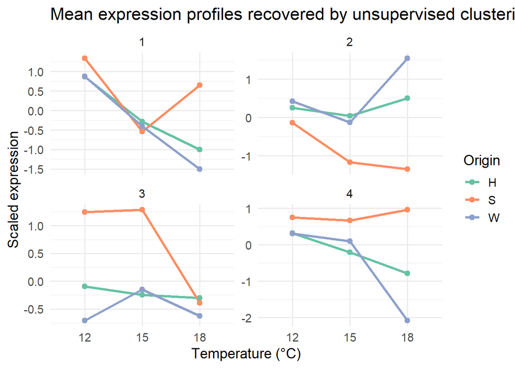

```
##
##
## Table: Cluster sizes for k = 4
##
## |Cluster | N_Genes|
## |:-------|-------:|
## |1       |      30|
## |2       |       7|
## |3       |       2|
## |4       |       6|
##
##
## Table: Cluster profiles for k = 4
##
## |Cluster |   W12|   W15|   W18|   H12|   H15|   H18|   S12|   S15|   S18|
## |:-------|-----:|-----:|-----:|-----:|-----:|-----:|-----:|-----:|-----:|
## |1       |  0.87| -0.40| -1.50|  0.86| -0.29| -1.01|  1.34| -0.53|  0.65|
## |2       |  0.43| -0.12|  1.55|  0.26|  0.04|  0.50| -0.14| -1.16| -1.34|
## |3       | -0.71| -0.15| -0.63| -0.10| -0.25| -0.30|  1.24|  1.28| -0.39|
## |4       |  0.30|  0.10| -2.08|  0.32| -0.21| -0.79|  0.75|  0.66|  0.95|
##
## ========================================
## k = 5
## ========================================
```

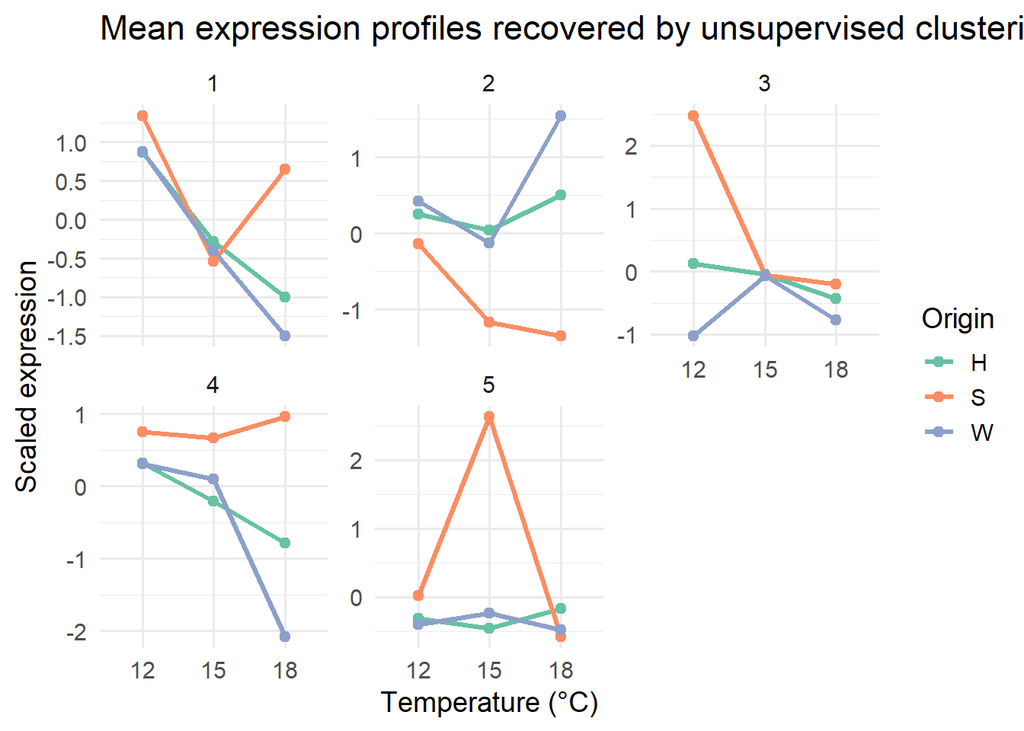

```
##
##
## Table: Cluster sizes for k = 5
##
## |Cluster | N_Genes|
## |:-------|-------:|
## |1       |      30|
## |2       |       7|
## |3       |       1|
## |4       |       6|
## |5       |       1|
##
##
## Table: Cluster profiles for k = 5
##
## |Cluster |   W12|   W15|   W18|   H12|   H15|   H18|   S12|   S15|   S18|
## |:-------|-----:|-----:|-----:|-----:|-----:|-----:|-----:|-----:|-----:|
## |1       |  0.87| -0.40| -1.50|  0.86| -0.29| -1.01|  1.34| -0.53|  0.65|
## |2       |  0.43| -0.12|  1.55|  0.26|  0.04|  0.50| -0.14| -1.16| -1.34|
## |3       | -1.02| -0.07| -0.77|  0.12| -0.05| -0.43|  2.47| -0.06| -0.20|
## |4       |  0.30|  0.10| -2.08|  0.32| -0.21| -0.79|  0.75|  0.66|  0.95|
## |5       | -0.40| -0.24| -0.48| -0.32| -0.45| -0.17|  0.02|  2.62| -0.58|
##
## ========================================
## k = 6
## ========================================
```

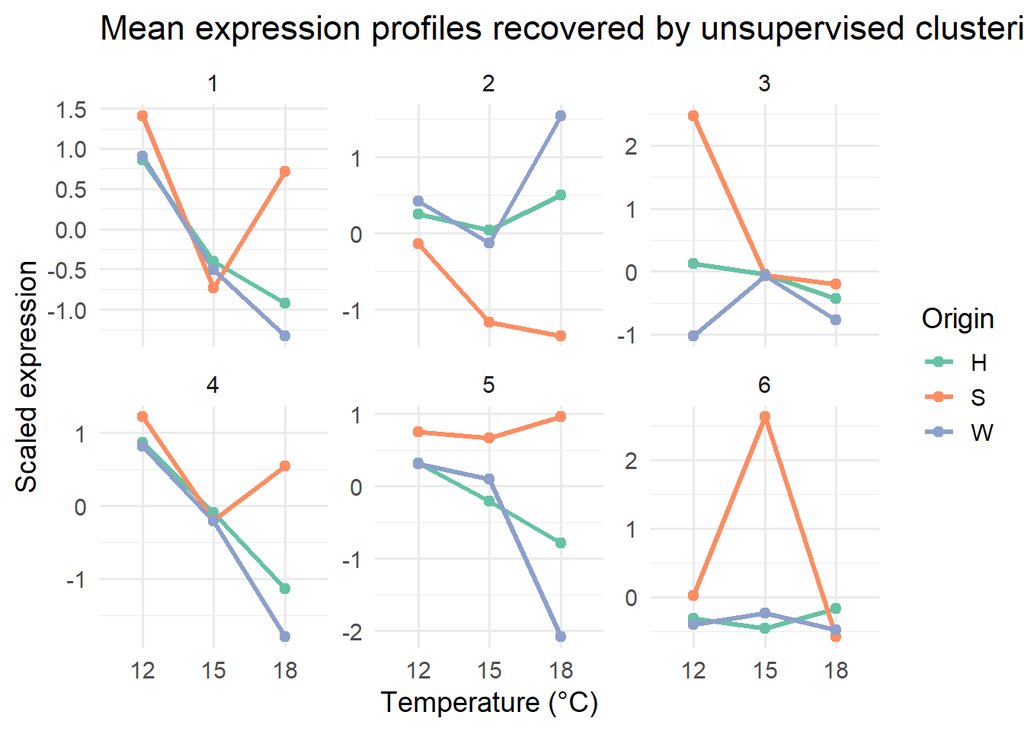

```
##
##
## Table: Cluster sizes for k = 6
##
## |Cluster | N_Genes|
## |:-------|-------:|
## |1       |      19|
## |2       |       7|
## |3       |       1|
## |4       |      11|
## |5       |       6|
## |6       |       1|
##
##
## Table: Cluster profiles for k = 6
##
## |Cluster |   W12|   W15|   W18|   H12|   H15|   H18|   S12|   S15|   S18|
## |:-------|-----:|-----:|-----:|-----:|-----:|-----:|-----:|-----:|-----:|
## |1       |  0.90| -0.51| -1.32|  0.86| -0.40| -0.93|  1.41| -0.73|  0.72|
## |2       |  0.43| -0.12|  1.55|  0.26|  0.04|  0.50| -0.14| -1.16| -1.34|
## |3       | -1.02| -0.07| -0.77|  0.12| -0.05| -0.43|  2.47| -0.06| -0.20|
## |4       |  0.81| -0.21| -1.80|  0.87| -0.09| -1.14|  1.22| -0.20|  0.54|
## |5       |  0.30|  0.10| -2.08|  0.32| -0.21| -0.79|  0.75|  0.66|  0.95|
## |6       | -0.40| -0.24| -0.48| -0.32| -0.45| -0.17|  0.02|  2.62| -0.58|
```

#### Cluster membership (k = 5)

```r
# Extract gene IDs assigned to each cluster for k = 5
tier2b_cluster_membership_k5 <- tibble(
  gene_id = names(tier2b_explore$k_5$clusters),
  cluster = tier2b_explore$k_5$clusters
)

# Display genes grouped by cluster
tier2b_cluster_membership_k5 %>%
  arrange(cluster) %>%
  group_by(cluster) %>%
  summarise(
    N_Genes = n(),
    Genes = paste(gene_id, collapse = ", "),
    .groups = "drop"
  ) %>%
  knitr::kable(
    caption = "Tier 2b gene membership by cluster (k = 5)"
  )
```

Tier 2b gene membership by cluster (k = 5)

| cluster | N_Genes | Genes |
| --- | --- | --- |
| 1 | 30 | TRINITY_GG_1293_c9_g3, TRINITY_GG_1604_c19_g4, TRINITY_GG_394_c173_g1, TRINITY_GG_446_c1914_g1, TRINITY_GG_394_c28_g1, TRINITY_GG_1406_c103_g1, TRINITY_GG_809_c60_g3, TRINITY_GG_867_c54_g1, TRINITY_GG… |
| 2 | 7 | TRINITY_GG_225_c768_g1, TRINITY_GG_1348_c8_g7, TRINITY_GG_595_c6_g2, TRINITY_GG_11_c0_g1, TRINITY_GG_489_c47_g1, TRINITY_GG_1600_c23_g3, TRINITY_GG_1008_c49_g2 |
| 3 | 1 | TRINITY_GG_759_c39_g1 |
| 4 | 6 | TRINITY_GG_951_c83_g1, TRINITY_GG_68_c39_g1, TRINITY_GG_282_c110_g1, TRINITY_GG_1263_c113_g2, TRINITY_GG_131_c6_g2, TRINITY_GG_234_c142_g3 |
| 5 | 1 | TRINITY_GG_722_c27_g2 |

#### Cluster annotations (k = 5)

```r
# Merge cluster assignments with annotations
tier2b_cluster_annotations <- tier2b_cluster_membership_k5 %>%
  left_join(
    annotations %>%
      select(
        gene_id,
        egg_desc,
        annotation_class,
        genome_gene_id,
        genome_coverage,
        has_eggnog,
        has_pfam_ipr,
        has_genome_uniprot
      ),
    by = "gene_id"
  ) %>%
  arrange(
    cluster,
    gene_id
  )

# Display annotated genes by cluster
tier2b_cluster_annotations %>%
  select(
    cluster,
    gene_id,
    egg_desc,
    annotation_class,
    genome_gene_id,
    genome_coverage
  ) %>%
  knitr::kable(
    caption = "Tier 2b annotated genes by cluster (k = 5)"
  )
```

Tier 2b annotated genes by cluster (k = 5)

| cluster | gene_id | egg_desc | annotation_class | genome_gene_id | genome_coverage |
| --- | --- | --- | --- | --- | --- |
| 1 | TRINITY_GG_1008_c51_g3 | Serine arginine-rich splicing factor | Well-annotated | FUNCG00000005947 | 95.69330 |
| 1 | TRINITY_GG_1293_c3278_g1 | NA | Unannotated | NA | NA |
| 1 | TRINITY_GG_1293_c52_g1 | Chromobox homolog 5 (HP1 alpha homolog; Drosophila) | Well-annotated | FUNCG00000015763 | 88.25510 |
| 1 | TRINITY_GG_1293_c9_g3 | Chromosome 20 open reading frame 24 | Well-annotated | FUNCG00000015961 | 71.15610 |
| 1 | TRINITY_GG_1334_c105_g1 | BRCA1-associated ATM activator 1 | Well-annotated | FUNCG00000003421 | 100.00000 |
| 1 | TRINITY_GG_1406_c103_g1 | Thiosulfate sulfurtransferase (rhodanese)-like | Well-annotated | FUNCG00000011385 | 90.96470 |
| 1 | TRINITY_GG_1505_c37_g1 | casein kinase | Well-annotated | FUNCG00000007062 | 66.06730 |
| 1 | TRINITY_GG_1505_c46_g1 | FK506 binding protein 14 | Well-annotated | FUNCG00000007034 | 56.91720 |
| 1 | TRINITY_GG_1505_c91_g5 | Cellular retinoic acid binding protein 2 | Well-annotated | FUNCG00000007234 | 85.05790 |
| 1 | TRINITY_GG_1586_c213_g1 | Von Willebrand factor C domain-containing protein 2-like | Well-annotated | FUNCG00000009761 | 31.32830 |
| 1 | TRINITY_GG_1586_c297_g6 | Myeloid-associated differentiation marker | Well-annotated | FUNCG00000009929 | 9.98754 |
| 1 | TRINITY_GG_1604_c19_g4 | NA | Unannotated | NA | NA |
| 1 | TRINITY_GG_1604_c19_g7 | NA | Unannotated | NA | NA |
| 1 | TRINITY_GG_234_c12_g5 | NA | Unannotated | NA | NA |
| 1 | TRINITY_GG_394_c173_g1 | Zinc finger; DHHC-type containing 18a | Well-annotated | FUNCG00000006959 | 58.02270 |
| 1 | TRINITY_GG_394_c28_g1 | Farnesyl diphosphate synthase (farnesyl pyrophosphate synthetase; dimethylallyltranstransferase; geranyltranstransferase) | Well-annotated | FUNCG00000007226 | 100.00000 |
| 1 | TRINITY_GG_394_c30_g4 | NA | Unannotated | NA | NA |
| 1 | TRINITY_GG_416_c2774_g1 | NA | Partially annotated | FUNCG00000020675 | 65.04590 |
| 1 | TRINITY_GG_446_c1914_g1 | Calreticulin; like 2 | Well-annotated | FUNCG00000010863 | 100.00000 |
| 1 | TRINITY_GG_486_c128_g1 | regulation of lipoprotein metabolic process | Well-annotated | FUNCG00000019611 | 100.00000 |
| 1 | TRINITY_GG_536_c7_g1 | Belongs to the Orn Lys Arg decarboxylase class-II family | Well-annotated | FUNCG00000021135 | 88.74960 |
| 1 | TRINITY_GG_555_c159_g2 | NA | Partially annotated | FUNCG00000005602 | 100.00000 |
| 1 | TRINITY_GG_597_c47_g1 | CD81 molecule | Well-annotated | FUNCG00000008463 | 100.00000 |
| 1 | TRINITY_GG_637_c152_g1 | membrane protein 2 | Well-annotated | FUNCG00000001060 | 100.00000 |
| 1 | TRINITY_GG_750_c167_g1 | vitamin K epoxide reductase complex subunit | Well-annotated | FUNCG00000023117 | 61.00810 |
| 1 | TRINITY_GG_809_c60_g3 | NA | Mapped only | FUNCG00000019651 | 20.57250 |
| 1 | TRINITY_GG_809_c6_g3 | NA | Unannotated | NA | NA |
| 1 | TRINITY_GG_820_c87_g1 | Prolyl 3-hydroxylase family member 4 (non-enzymatic) | Well-annotated | FUNCG00000019395 | 100.00000 |
| 1 | TRINITY_GG_867_c54_g1 | NA | Partially annotated | FUNCG00000010646 | 28.73600 |
| 1 | TRINITY_GG_936_c54_g1 | Calcium homeostasis modulator | Well-annotated | FUNCG00000017200 | 46.34150 |
| 2 | TRINITY_GG_1008_c49_g2 | Dysbindin (dystrobrevin binding protein 1) domain containing 2 | Well-annotated | FUNCG00000005472 | 90.54070 |
| 2 | TRINITY_GG_11_c0_g1 | NA | Unannotated | NA | NA |
| 2 | TRINITY_GG_1348_c8_g7 | E3 ubiquitin-protein ligase | Well-annotated | FUNCG00000022457 | 71.71490 |
| 2 | TRINITY_GG_1600_c23_g3 | Belongs to the beta gamma-crystallin family | Well-annotated | FUNCG00000017036 | 100.00000 |
| 2 | TRINITY_GG_225_c768_g1 | YTH domain containing 1 | Well-annotated | FUNCG00000018859 | 13.17360 |
| 2 | TRINITY_GG_489_c47_g1 | PHD-zinc-finger like domain | Well-annotated | FUNCG00000019279 | 68.71170 |
| 2 | TRINITY_GG_595_c6_g2 | NA | Partially annotated | FUNCG00000007877 | 62.23720 |
| 3 | TRINITY_GG_759_c39_g1 | Transmembrane 6 superfamily member 1 | Well-annotated | FUNCG00000004480 | 99.94880 |
| 4 | TRINITY_GG_1263_c113_g2 | Solute carrier family 22 | Well-annotated | FUNCG00000013908 | 85.37560 |
| 4 | TRINITY_GG_131_c6_g2 | NA | Partially annotated | FUNCG00000022476 | 100.00000 |
| 4 | TRINITY_GG_234_c142_g3 | NA | Unannotated | NA | NA |
| 4 | TRINITY_GG_282_c110_g1 | Family with sequence similarity 198 member B | Well-annotated | FUNCG00000023673 | 100.00000 |
| 4 | TRINITY_GG_68_c39_g1 | Leucine rich repeat N-terminal domain | Well-annotated | FUNCG00000023959 | 100.00000 |
| 4 | TRINITY_GG_951_c83_g1 | Transmembrane protein 150A-like | Well-annotated | FUNCG00000017714 | 100.00000 |
| 5 | TRINITY_GG_722_c27_g2 | Sterile alpha motif domain-containing protein 9-like | Well-annotated | NA | NA |

Silhouette width was highest for k = 2 (0.663) and declined with increasing cluster number. However, the k = 5 solution retained similar clustering support to k = 4 (0.465 vs. 0.461) while recovering two additional biologically interpretable singleton trajectories corresponding to the well annotated genes Sterile alpha motif domain-containing protein 9-like and Transmembrane 6 superfamily member 1. In contrast, clustering solutions beyond k = 5 resulted in a marked reduction in silhouette width (0.289 for k = 6), indicating limited support for further subdivision. We therefore retained k = 5 as the most biologically informative clustering solution.

Cluster 1 (30 genes)

West: progressive decrease Hybrid: progressive decrease (reduced magnitude) South: transient valley followed by recovery

Cluster 2 (7 genes)

West: transient valley Hybrid: transient valley (reduced magnitude) South: progressive decrease

West: transient peak Hybrid: progressive decrease (low magnitude, near-stable expression) South: progressive decrease (strong magnitude from elevated 12°C expression)

Cluster 4 (6 genes)

West: progressive decrease Hybrid: progressive decrease (reduced magnitude) South: transient valley

West: transient peak (low magnitude) Hybrid: transient valley (low magnitude) South: transient peak (pronounced peak at 15°C)

### Tier 3 Misexpressed Genes

```r
tier3_k <- evaluate_k(
  build_profile_matrix(
    tier3_mis_genes,
    expr_matrix,
    metadata
  )
)

knitr::kable(
  tier3_k,
  digits = 3
)
```

| k | Mean_Silhouette | N_Clusters | Largest_Cluster | Smallest_Cluster |
| --- | --- | --- | --- | --- |
| 2 | 0.332 | 2 | 387 | 340 |
| 3 | 0.264 | 3 | 387 | 123 |
| 4 | 0.220 | 4 | 287 | 100 |
| 5 | 0.216 | 5 | 231 | 56 |
| 6 | 0.174 | 6 | 231 | 56 |
| 7 | 0.123 | 7 | 148 | 56 |
| 8 | 0.132 | 8 | 148 | 56 |
| 9 | 0.141 | 9 | 148 | 29 |
| 10 | 0.146 | 10 | 148 | 23 |
| 11 | 0.131 | 11 | 148 | 23 |
| 12 | 0.126 | 12 | 148 | 23 |

```r
tier3_explore <- explore_clusters(
  gene_set = tier3_mis_genes,
  expr_matrix = expr_matrix,
  metadata = metadata,
  k_values = c(2,3,4)
)
```

```
##
## ========================================
## k = 2
## ========================================
```

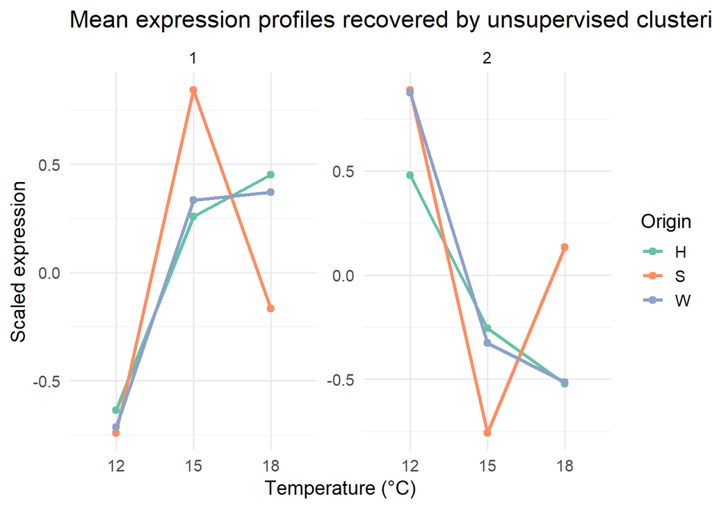

```
##
##
## Table: Cluster sizes for k = 2
##
## |Cluster | N_Genes|
## |:-------|-------:|
## |1       |     340|
## |2       |     387|
##
##
## Table: Cluster profiles for k = 2
##
## |Cluster |   W12|   W15|   W18|   H12|   H15|   H18|   S12|   S15|   S18|
## |:-------|-----:|-----:|-----:|-----:|-----:|-----:|-----:|-----:|-----:|
## |1       | -0.72|  0.33|  0.37| -0.64|  0.26|  0.45| -0.74|  0.84| -0.17|
## |2       |  0.88| -0.33| -0.51|  0.48| -0.26| -0.52|  0.89| -0.76|  0.13|
##
## ========================================
## k = 3
## ========================================
```

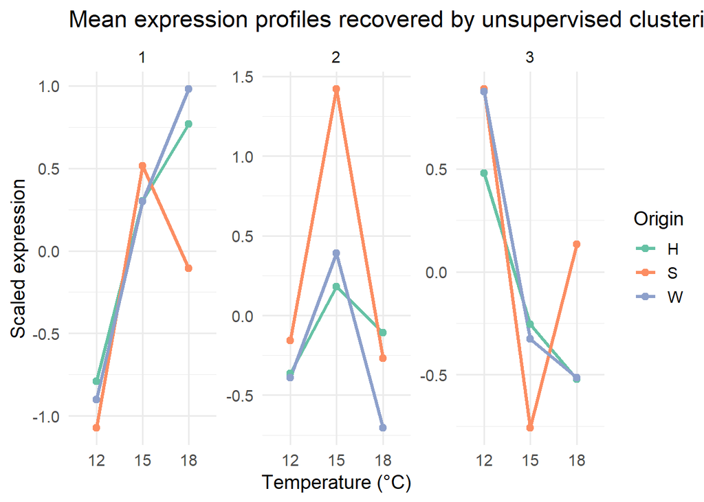

```
##
##
## Table: Cluster sizes for k = 3
##
## |Cluster | N_Genes|
## |:-------|-------:|
## |1       |     217|
## |2       |     123|
## |3       |     387|
##
##
## Table: Cluster profiles for k = 3
##
## |Cluster |   W12|   W15|   W18|   H12|   H15|   H18|   S12|   S15|   S18|
## |:-------|-----:|-----:|-----:|-----:|-----:|-----:|-----:|-----:|-----:|
## |1       | -0.90|  0.30|  0.98| -0.79|  0.30|  0.77| -1.07|  0.52| -0.11|
## |2       | -0.39|  0.39| -0.71| -0.36|  0.18| -0.11| -0.16|  1.42| -0.27|
## |3       |  0.88| -0.33| -0.51|  0.48| -0.26| -0.52|  0.89| -0.76|  0.13|
##
## ========================================
## k = 4
## ========================================
```

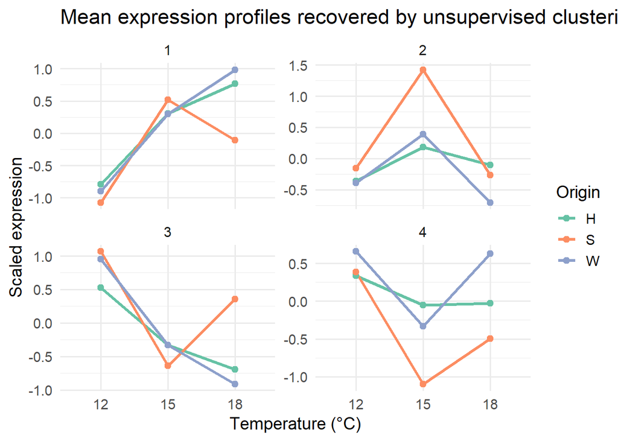

```
##
##
## Table: Cluster sizes for k = 4
##
## |Cluster | N_Genes|
## |:-------|-------:|
## |1       |     217|
## |2       |     123|
## |3       |     287|
## |4       |     100|
##
##
## Table: Cluster profiles for k = 4
##
## |Cluster |   W12|   W15|   W18|   H12|   H15|   H18|   S12|   S15|   S18|
## |:-------|-----:|-----:|-----:|-----:|-----:|-----:|-----:|-----:|-----:|
## |1       | -0.90|  0.30|  0.98| -0.79|  0.30|  0.77| -1.07|  0.52| -0.11|
## |2       | -0.39|  0.39| -0.71| -0.36|  0.18| -0.11| -0.16|  1.42| -0.27|
## |3       |  0.95| -0.33| -0.91|  0.53| -0.33| -0.69|  1.07| -0.64|  0.35|
## |4       |  0.66| -0.33|  0.63|  0.33| -0.05| -0.03|  0.38| -1.10| -0.50|
```

Tier 3 Misexpressed genes exhibited substantially weaker clustering structure than the other gene sets, with a maximum silhouette width of 0.332 for k = 2. This suggests that hybrid misexpression is distributed across a diverse range of transcriptional response patterns rather than being dominated by a small number of discrete trajectory classes. Because k = 2 provided the strongest clustering support, we retained this solution for subsequent interpretation.

West: progressive increase Hybrid: progressive increase South: transient peak

West: progressive decrease Hybrid: progressive decrease (reduced magnitude) South: transient valley

The two clusters were of comparable size and represent broad opposing transcriptional response patterns. Cluster 1 was characterized by increasing expression with temperature in West and Hybrid fish together with a transient peak response in South fish, whereas Cluster 2 exhibited decreasing expression in West and Hybrid fish and a transient valley response in South fish. However, the relatively low silhouette widths and the absence of additional well-supported trajectory classes indicate that misexpressed genes do not form a small number of discrete expression programs. Instead, hybrid misexpression appears to be distributed across diverse transcriptional response patterns, consistent with the heterogeneous nature of regulatory incompatibilities.

### Tier 1 ∩ Tier 3 Misexpressed Genes

#### Evaluation of clustering solutions

```r
# Evaluate clustering solutions
tier1_tier3_k <- evaluate_k(
  build_profile_matrix(
    tier1_tier3_mis_genes,
    expr_matrix,
    metadata
  )
)

knitr::kable(
  tier1_tier3_k,
  digits = 3
)
```

| k | Mean_Silhouette | N_Clusters | Largest_Cluster | Smallest_Cluster |
| --- | --- | --- | --- | --- |
| 2 | 0.627 | 2 | 13 | 10 |
| 3 | 0.587 | 3 | 10 | 5 |
| 4 | 0.549 | 4 | 8 | 3 |
| 5 | 0.490 | 5 | 8 | 1 |
| 6 | 0.446 | 6 | 8 | 1 |
| 7 | 0.404 | 7 | 8 | 1 |
| 8 | 0.302 | 8 | 7 | 1 |
| 9 | 0.296 | 9 | 7 | 1 |
| 10 | 0.246 | 10 | 7 | 1 |
| 11 | 0.208 | 11 | 5 | 1 |
| 12 | 0.193 | 12 | 5 | 1 |

```r
# Explore clustering solutions
tier1_tier3_explore <- explore_clusters(
  gene_set = tier1_tier3_mis_genes,
  expr_matrix = expr_matrix,
  metadata = metadata,
  k_values = c(2, 3, 4, 5)
)
```

```
##
## ========================================
## k = 2
## ========================================
```

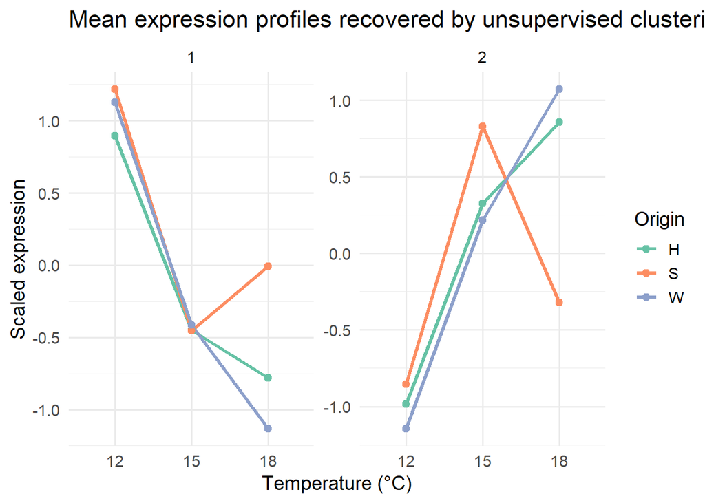

```
##
##
## Table: Cluster sizes for k = 2
##
## |Cluster | N_Genes|
## |:-------|-------:|
## |1       |      13|
## |2       |      10|
##
##
## Table: Cluster profiles for k = 2
##
## |Cluster |   W12|   W15|   W18|   H12|   H15|   H18|   S12|   S15|   S18|
## |:-------|-----:|-----:|-----:|-----:|-----:|-----:|-----:|-----:|-----:|
## |1       |  1.13| -0.41| -1.13|  0.89| -0.45| -0.78|  1.22| -0.46| -0.01|
## |2       | -1.15|  0.22|  1.07| -0.98|  0.33|  0.86| -0.85|  0.83| -0.32|
##
## ========================================
## k = 3
## ========================================
```

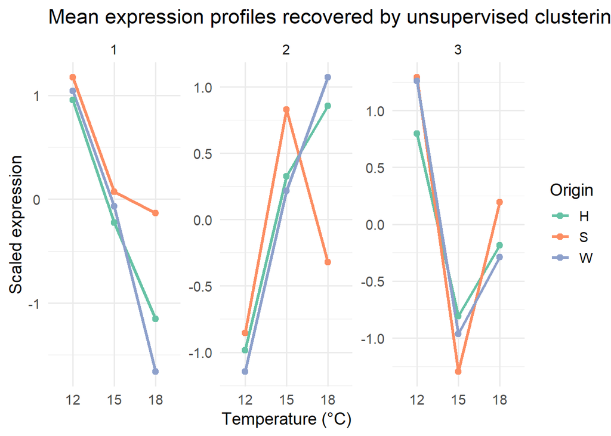

```
##
##
## Table: Cluster sizes for k = 3
##
## |Cluster | N_Genes|
## |:-------|-------:|
## |1       |       8|
## |2       |      10|
## |3       |       5|
##
##
## Table: Cluster profiles for k = 3
##
## |Cluster |   W12|   W15|   W18|   H12|   H15|   H18|   S12|   S15|   S18|
## |:-------|-----:|-----:|-----:|-----:|-----:|-----:|-----:|-----:|-----:|
## |1       |  1.04| -0.07| -1.66|  0.95| -0.23| -1.15|  1.17|  0.07| -0.13|
## |2       | -1.15|  0.22|  1.07| -0.98|  0.33|  0.86| -0.85|  0.83| -0.32|
## |3       |  1.26| -0.96| -0.29|  0.80| -0.81| -0.19|  1.29| -1.30|  0.19|
##
## ========================================
## k = 4
## ========================================
```

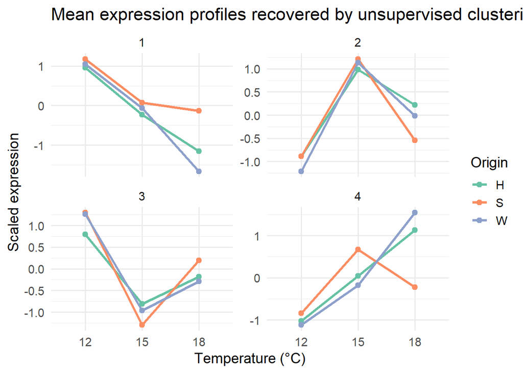

```
##
##
## Table: Cluster sizes for k = 4
##
## |Cluster | N_Genes|
## |:-------|-------:|
## |1       |       8|
## |2       |       3|
## |3       |       5|
## |4       |       7|
##
##
## Table: Cluster profiles for k = 4
##
## |Cluster |   W12|   W15|   W18|   H12|   H15|   H18|   S12|   S15|   S18|
## |:-------|-----:|-----:|-----:|-----:|-----:|-----:|-----:|-----:|-----:|
## |1       |  1.04| -0.07| -1.66|  0.95| -0.23| -1.15|  1.17|  0.07| -0.13|
## |2       | -1.21|  1.13| -0.02| -0.88|  0.98|  0.22| -0.88|  1.21| -0.54|
## |3       |  1.26| -0.96| -0.29|  0.80| -0.81| -0.19|  1.29| -1.30|  0.19|
## |4       | -1.12| -0.17|  1.54| -1.03|  0.05|  1.13| -0.84|  0.67| -0.22|
##
## ========================================
## k = 5
## ========================================
```

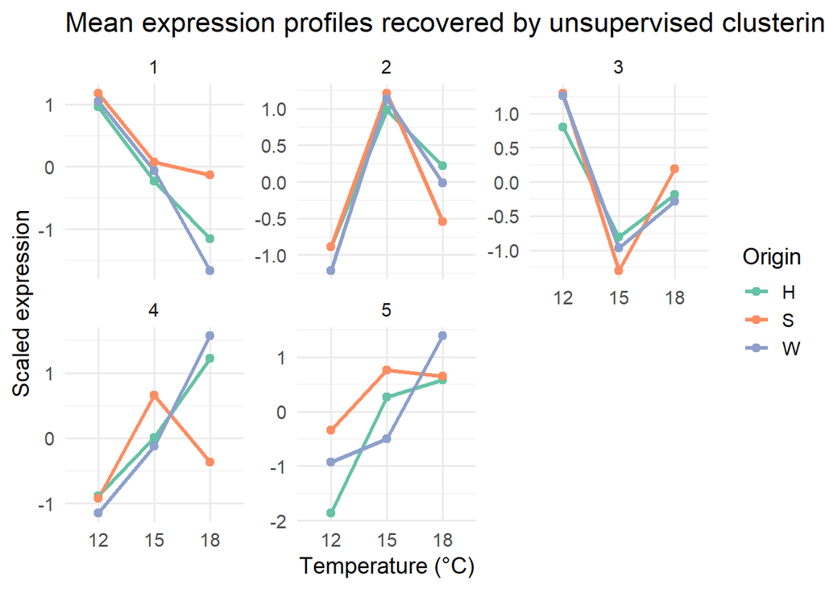

```
##
##
## Table: Cluster sizes for k = 5
##
## |Cluster | N_Genes|
## |:-------|-------:|
## |1       |       8|
## |2       |       3|
## |3       |       5|
## |4       |       6|
## |5       |       1|
##
##
## Table: Cluster profiles for k = 5
##
## |Cluster |   W12|   W15|   W18|   H12|   H15|   H18|   S12|   S15|   S18|
## |:-------|-----:|-----:|-----:|-----:|-----:|-----:|-----:|-----:|-----:|
## |1       |  1.04| -0.07| -1.66|  0.95| -0.23| -1.15|  1.17|  0.07| -0.13|
## |2       | -1.21|  1.13| -0.02| -0.88|  0.98|  0.22| -0.88|  1.21| -0.54|
## |3       |  1.26| -0.96| -0.29|  0.80| -0.81| -0.19|  1.29| -1.30|  0.19|
## |4       | -1.15| -0.12|  1.57| -0.89|  0.01|  1.22| -0.92|  0.65| -0.37|
## |5       | -0.93| -0.50|  1.38| -1.86|  0.27|  0.58| -0.35|  0.75|  0.65|
```

####Cluster membership (k = 4)

```r
# Extract gene IDs assigned to each cluster for k = 4
tier1_tier3_cluster_membership_k4 <- tibble(
  gene_id = names(tier1_tier3_explore$k_4$clusters),
  cluster = tier1_tier3_explore$k_4$clusters
)

# Display genes grouped by cluster
tier1_tier3_cluster_membership_k4 %>%
  arrange(cluster) %>%
  group_by(cluster) %>%
  summarise(
    N_Genes = n(),
    Genes = paste(gene_id, collapse = ", "),
    .groups = "drop"
  ) %>%
  knitr::kable(
    caption = "Tier 1 ∩ Tier 3 gene membership by cluster (k = 4)"
  )
```

Tier 1 ∩ Tier 3 gene membership by cluster (k = 4)

| cluster | N_Genes | Genes |
| --- | --- | --- |
| 1 | 8 | TRINITY_GG_597_c30_g1, TRINITY_GG_416_c23_g1, TRINITY_GG_957_c157_g1, TRINITY_GG_415_c12_g1, TRINITY_GG_1118_c12_g1, TRINITY_GG_1115_c7_g6, TRINITY_GG_370_c127_g1, TRINITY_GG_448_c236_g1 |
| 2 | 3 | TRINITY_GG_1219_c1_g1, TRINITY_GG_283_c70_g1, TRINITY_GG_131_c77_g5 |
| 3 | 5 | TRINITY_GG_866_c19_g1, TRINITY_GG_225_c3_g1, TRINITY_GG_602_c87_g1, TRINITY_GG_1503_c14_g3, TRINITY_GG_1462_c182_g1 |
| 4 | 7 | TRINITY_GG_722_c7_g3, TRINITY_GG_165_c3_g1, TRINITY_GG_1107_c123_g1, TRINITY_GG_867_c1_g3, TRINITY_GG_234_c4_g1, TRINITY_GG_595_c167_g1, TRINITY_GG_446_c69_g1 |

#### Cluster annotations (k = 4)

```r
# Merge cluster assignments with annotations
tier1_tier3_cluster_annotations <- tier1_tier3_cluster_membership_k4 %>%
  left_join(
    annotations %>%
      select(
        gene_id,
        egg_desc,
        annotation_class,
        genome_gene_id,
        genome_coverage,
        has_eggnog,
        has_pfam_ipr,
        has_genome_uniprot
      ),
    by = "gene_id"
  ) %>%
  arrange(
    cluster,
    gene_id
  )

# Display annotated genes by cluster
tier1_tier3_cluster_annotations %>%
  select(
    cluster,
    gene_id,
    egg_desc,
    annotation_class,
    genome_gene_id,
    genome_coverage
  ) %>%
  knitr::kable(
    caption = "Tier 1 ∩ Tier 3 annotated genes by cluster (k = 4)"
  )
```

Tier 1 ∩ Tier 3 annotated genes by cluster (k = 4)

| cluster | gene_id | egg_desc | annotation_class | genome_gene_id | genome_coverage |
| --- | --- | --- | --- | --- | --- |
| 1 | TRINITY_GG_1115_c7_g6 | NA | Unannotated | NA | NA |
| 1 | TRINITY_GG_1118_c12_g1 | A disintegrin and metalloprotease domain 10a;constitutive protein ectodomain proteolysis | Well-annotated | FUNCG00000004678 | 100.0000 |
| 1 | TRINITY_GG_370_c127_g1 | RAB31; member RAS oncogene family | Well-annotated | FUNCG00000009861 | 100.0000 |
| 1 | TRINITY_GG_415_c12_g1 | Persistent plexus | Well-annotated | FUNCG00000020237 | 100.0000 |
| 1 | TRINITY_GG_416_c23_g1 | FK506 binding protein 14;Collagen-like tail subunit (single strand of homotrimer) of asymmetric acetylcholinesterase | Well-annotated | FUNCG00000020387 | 79.4637 |
| 1 | TRINITY_GG_448_c236_g1 | Belongs to the cation transport ATPase (P-type) (TC 3.A.3) family. Type IV subfamily | Well-annotated | FUNCG00000010402 | 95.9659 |
| 1 | TRINITY_GG_597_c30_g1 | Transfers N-acetylgalactosamine (GalNAc) from UDP-GalNAc to N-acetylglucosamine-beta-benzyl with a beta-1;4-linkage to form N;N’-diacetyllactosediamine; GalNAc-beta-1;4-GlcNAc structures in N-linked g… | Well-annotated | FUNCG00000008317 | 100.0000 |
| 1 | TRINITY_GG_957_c157_g1 | Belongs to the TRAFAC class myosin-kinesin ATPase superfamily. Myosin family | Well-annotated | FUNCG00000008486 | 100.0000 |
| 2 | TRINITY_GG_1219_c1_g1 | Ethanolamine kinase 1 | Well-annotated | FUNCG00000024136 | 97.8974 |
| 2 | TRINITY_GG_131_c77_g5 | ATP-binding cassette sub-family A member 1-like | Well-annotated | FUNCG00000022378 | 93.4579 |
| 2 | TRINITY_GG_283_c70_g1 | F-box and leucine-rich repeat protein 21 (gene pseudogene) | Well-annotated | FUNCG00000011819 | 51.8221 |
| 3 | TRINITY_GG_1462_c182_g1 | Belongs to the phosphoglycerate mutase family. BPG- dependent PGAM subfamily | Well-annotated | FUNCG00000018526 | 37.9162 |
| 3 | TRINITY_GG_1503_c14_g3 | Enoyl Coenzyme A hydratase domain containing 1 | Well-annotated | FUNCG00000006867 | 55.9541 |
| 3 | TRINITY_GG_225_c3_g1 | AIG1 family | Well-annotated | FUNCG00000018722 | 100.0000 |
| 3 | TRINITY_GG_602_c87_g1 | Transmembrane protein 150A-like | Well-annotated | FUNCG00000017720 | 66.5939 |
| 3 | TRINITY_GG_866_c19_g1 | Chromosome 8 open reading frame 82;Nicotinate phosphoribosyltransferase;Chromosome 19 open reading frame 25 | Well-annotated | FUNCG00000014268 | 100.0000 |
| 4 | TRINITY_GG_1107_c123_g1 | 5-methyltetrahydrofolate-homocysteine methyltransferase;Nuclease-related domain | Well-annotated | FUNCG00000022689 | 100.0000 |
| 4 | TRINITY_GG_165_c3_g1 | carbohydrate binding;Galactose binding lectin domain | Well-annotated | FUNCG00000015474 | 95.4653 |
| 4 | TRINITY_GG_234_c4_g1 | Belongs to the TRAFAC class myosin-kinesin ATPase superfamily. Kinesin family;Kinesin heavy chain member 2A;Solute carrier family 35 member | Well-annotated | FUNCG00000018307 | 98.1595 |
| 4 | TRINITY_GG_446_c69_g1 | Cystathionine gamma-lyase | Well-annotated | FUNCG00000010579 | 98.0412 |
| 4 | TRINITY_GG_595_c167_g1 | Leucine-rich repeat-containing protein | Well-annotated | FUNCG00000008204 | 100.0000 |
| 4 | TRINITY_GG_722_c7_g3 | NIMA-related kinase 5 | Well-annotated | FUNCG00000015187 | 62.8664 |
| 4 | TRINITY_GG_867_c1_g3 | Chloride channel CLIC-like;G-protein coupled receptor activity | Well-annotated | FUNCG00000010607 | 100.0000 |

Silhouette width was highest for k = 2 (0.627) and declined gradually with increasing cluster number. However, the k = 4 solution retained relatively strong clustering support (0.549) while resolving four distinct multi-origin expression patterns. Compared with the k = 3 solution, k = 4 separated a broad cluster containing increasing-expression genes into two distinct response profiles, one characterized by transient peak responses across all origins and another characterized by progressive increases in West and Hybrid fish together with a transient peak response in South fish. Beyond k = 4, silhouette width declined more sharply from 0.549 to 0.490 and continued to decrease with increasing cluster number, indicating diminishing support for additional subdivision. We therefore retained k = 4 as the most biologically informative clustering solution.

Cluster 1 (8 genes)

West: progressive decrease (strongest magnitude) Hybrid: progressive decrease (intermediate magnitude) South: weak progressive decrease (lowest magnitude)

Cluster 2 (3 genes)

West: transient peak Hybrid: transient peak (lowest magnitude) South: transient peak (strongest magnitude)

Cluster 3 (5 genes)

West: transient valley Hybrid: transient valley (weakest magnitude) South: transient valley (strongest magnitude)

Cluster 4 (7 genes)

West: progressive increase Hybrid: progressive increase (lower magnitude) South: transient peak

These results indicate that misexpressed Tier 1 genes are distributed across multiple transcriptional response patterns. Notably, the k = 4 solution recovered the same major response architectures observed in the broader Tier 1 gene set, despite representing only 23 genes. Functional annotations were diverse across all four clusters and did not reveal obvious cluster-specific functional categories. This suggests that hybrid misexpression is not restricted to a particular subset of conserved temperature-responsive genes, but instead affects genes spanning several distinct temperature-response programs and biological functions.

### Summary

Hierarchical clustering revealed that different gene sets were characterized by distinct transcriptional response architectures. Tier 1 genes recovered multiple temperature-response patterns, but a consistent feature across clusters was that Southern fish exhibited stronger non-linear responses than Western and Hybrid fish, whereas hybrid trajectories generally resembled those of Western fish with reduced response magnitudes. In contrast, Tier 2 genes were dominated by two broad expression programs, demonstrating that transcriptional differences among populations can arise through both differences in expression level despite similar response trajectories and differences in the trajectory of the transcriptional response itself.

Interaction genes and Tier 2b local adaptation candidates exhibited the strongest evidence for origin-specific thermal responses. In both gene sets, Western and Hybrid fish frequently followed similar trajectories, whereas Southern fish showed distinct and often more pronounced non-linear responses. Tier 2b candidates were particularly notable because most genes exhibited their strongest population-specific expression differences under the warmest treatment, consistent with the strong increase in parental divergence observed at 18°C. Nevertheless, the singleton trajectories represented by SAMD9L and TM6SF1 demonstrated that unique population-specific responses can also occur at lower temperatures.

In contrast, Tier 3 misexpressed genes exhibited comparatively weak clustering structure despite comprising hundreds of genes. Misexpressed genes were distributed across multiple response architectures, and the Tier 1 ∩ Tier 3 overlap recovered the same major trajectory patterns observed in the broader Tier 1 gene set. Together with the limited overlap of misexpressed genes across temperatures observed in the Tier 3 analysis, these results indicate that hybrid misexpression is distributed across diverse genes and transcriptional response patterns rather than concentrated within a distinct regulatory program.

## Individual gene trajectories

### Plotting helper function

```r
# ------------------------------------------------------------
# Faceted gene trajectory plot with SD
# ------------------------------------------------------------

plot_gene_panel <- function(
    gene_ids,
    expr_matrix,
    metadata,
    title_text
){

  plot_df <- lapply(

    gene_ids,

    function(gene){

      data.frame(
        sample = colnames(expr_matrix),
        Expression = as.numeric(expr_matrix[gene, ])
      ) %>%
        left_join(
          metadata,
          by = "sample"
        ) %>%
        group_by(
          origin,
          temperature
        ) %>%
        summarise(
          Mean_Expression = mean(Expression),
          SD = sd(Expression),
          N = n(),
          .groups = "drop"
        ) %>%
        mutate(
          Gene = gene
        )

    }

  ) %>%
    bind_rows()

  p <- ggplot(
    plot_df,
    aes(
      x = temperature,
      y = Mean_Expression,
      colour = origin,
      group = origin
    )
  ) +
    geom_line(linewidth = 0.8) +
    geom_point(size = 1.8) +
    geom_errorbar(
      aes(
        ymin = Mean_Expression - SD,
        ymax = Mean_Expression + SD
      ),
      width = 0.1,
      linewidth = 0.3
    ) +
    scale_colour_manual(
      values = origin_colors
    ) +
    facet_wrap(
      ~ Gene,
      scales = "free_y"
    ) +
    labs(
      title = title_text,
      x = "Temperature (°C)",
      y = "Mean VST expression"
    ) +
    theme_minimal(base_size = 12)

  return(p)

}
```